# Análisis de residuos 2

# Instalación

```r
# paquetes ==========================================================
library(tidyverse)
# paleta de colores p. 422
library(RColorBrewer)
# letter value plot p. 99 (inglés)
library(lvplot)
# # calcular la moda
# library(DescTools)
# # coeficiente de asimetría
# library(moments)
# library(EnvStats)
library(modelr)
# análisis de residuos
library(performance)
library(car)
library(stats)
library(nortest)
library(moments)
library(lmtest)
library(see)

# importación =======================================================
# 3. sociodemográfica
sdem <- read_csv(
  "enoet22025/ENOE_SDEMT225.csv",
  col_types = cols(.default = col_character())
)

# 4. ocupación y empleo I
coe1 <- read_csv(
  "enoet22025/ENOE_COE1T225.csv",
  col_types = cols(.default = col_character())
)

# 5. ocupación y empleo II
coe2 <- read_csv(
  "enoet22025/ENOE_COE2T225.csv",
  col_types = cols(.default = col_character())
)

# segmentación ======================================================
sdem<- sdem %>% mutate(
  # edad
  eda = as.integer(eda),
  # años de escolaridad
  escolaridad = as.integer(anios_esc),
  # 99 pasa a NA para evitar 99 - edu_req
  escolaridad = if_else(escolaridad != 99, escolaridad, NA),
  # ponderador trimestral
  fac_tri = as.double(fac_tri),
  # ingreso mensual
  ing_mensual = as.double(ingocup),
  # 0 pasa a NA ya que 0==NA en p6b2
  ing_mensual = if_else(ing_mensual != 0, ing_mensual, NA),
  # promedio de ingreso por hora
  ing_hora = as.double(ing_x_hrs),
  # 0 pasa a NA ya que 0==NA en p6b2 y en dur9c == 1 & 9
  ing_hora = if_else(ing_hora != 0, ing_hora, NA)
)

# construcción de variables =========================================
# grupos de edad OECD(2019: 135)
sdem <- sdem %>%
  mutate(
    edad_7g = case_when(
      between(eda, 0, 14) ~ "1",
      between(eda, 15, 24) ~ "2",
      between(eda, 25, 34) ~ "3",
      between(eda, 35, 44) ~ "4",
      between(eda, 45, 54) ~ "5",
      between(eda, 55, 64) ~ "6",
      between(eda, 65, 97) ~ "7",
      # edad no especificada mayores a 12 INEGI(2024:16)
      eda == "98" ~ "98",
      # edad no especificada menores a 12 INEGI(2024:16)
      eda == "99" ~ "99",
      # NA sin comillas para valores faltantes
      TRUE ~ NA
    )
  )

# carreras universitaria INEGI(2016: 13)
sdem <- sdem %>%
  mutate(
    carrera1 = if_else(str_length(cs_p14_c) == 5, str_c("0", cs_p14_c), cs_p14_c),
    carrera2 = if_else(str_length(cs_p14_c) == 5, str_c("0", cs_p14_c), cs_p14_c),
    carrera3 = if_else(str_length(cs_p14_c) == 5, str_c("0", cs_p14_c), cs_p14_c)
  ) %>%
  separate(
    carrera1,
    # campo amplio
    into = c("carrera1", "res"),
    sep = 2
  ) %>%
  separate(
    carrera2,
    # campo específico
    into = c("carrera2", "res"),
    sep = 3
  ) %>%
  separate(
    carrera3,
    # campo detallado
    into = c("carrera3", "res"),
    sep = 4
  ) %>%
  select(-res)

# grupos ocupacionales INEGI(2019: 22)
coe1 <- coe1 %>%
  mutate(
    ocupacion1 = p3,
    ocupacion2 = p3
  ) %>%
  separate(
    ocupacion1,
    into = c("ocupacion1", "res"),
    sep = 1
  ) %>%
  separate(
    ocupacion2,
    into = c("ocupacion2", "res"),
    sep = 2
  ) %>%
  select(-res)

# creación de tablas ================================================
# población total INEGI(2023:21)
pob_total <- sdem %>%
  filter(
    r_def == "0",
    # es igual a (c_res == "1" | c_res == "3")
    c_res != "2"
  )

# población de 12 y más para unir sdem y coe INEGI(2023:9)
pob_12ymas <- sdem %>%
  filter(
  r_def == "0",
  c_res != "2",
  between(eda, 12, 98)
  )

# unión de sdem y coe INEGI(2023:9)
completo <- pob_12ymas %>%
  full_join(coe1, by = c("tipo", "mes_cal", "ent", "con", "v_sel", "n_hog", "h_mud", "n_ren")) %>%
  full_join(coe2, by = c("tipo", "mes_cal", "ent", "con", "v_sel", "n_hog", "h_mud", "n_ren"))

# población de 15 años y más INEGI(2023:21)
pob_15ymas <- completo %>%
  filter(
    r_def.x == "0",
    c_res != "2",
    between(eda.x, 15, 98)
  )

# INEGI(2023: 21)
ocupada <- pob_15ymas %>%
  filter(clase2 == 1)

# INEGI(2023: 25)
desocupada <- pob_15ymas %>%
  filter(clase2 == 2)

# INEGI(2023: 26)
pnea <- pob_15ymas %>%
  filter(clase1 == 2)

# sobre-educación ===================================================

# con el grupo división INEGI(2020: 22) -----------------------------
# métodos: verdugo y verdugo, y mediana
edu_req1_ocu1 <- ocupada %>%
  filter(!is.na(escolaridad)) %>%
  group_by(ocupacion1) %>%
  summarise(
    vv_neg_ocu1 = mean(escolaridad) - sd(escolaridad),
    vv_pos_ocu1 = mean(escolaridad) + sd(escolaridad),
    mediana_ocu1 = median(escolaridad)
  )

# método: moda
edu_req2_ocu1 <- ocupada %>%
  filter(!is.na(escolaridad)) %>%
  group_by(ocupacion1, escolaridad) %>%
  summarise(
    tot = sum(fac_tri.x)
  ) %>%
    filter(tot == max(tot)) %>%
    rename("moda_ocu1" = "escolaridad") %>%
    select(-tot)

# variable de desajuste educativo
ocupada <- ocupada %>% left_join(edu_req1_ocu1, by = "ocupacion1") %>%
  left_join(edu_req2_ocu1, by = "ocupacion1") %>%
  mutate(
    escolaridad = as.double(escolaridad),
    moda_ocu1 = as.double(moda_ocu1),
    # verdugo y verdugo
    edu_mis_vv_ocu1 = case_when(
      # required
      between(escolaridad, vv_neg_ocu1, vv_pos_ocu1) ~ 0,
      # over
      escolaridad > vv_pos_ocu1 ~ 1,
      # under
      escolaridad < vv_neg_ocu1 ~ 2,
      TRUE ~ NA
    ),
    # mediana
    edu_mis_med_ocu1 = case_when(
      # required
      escolaridad == mediana_ocu1 ~ 0,
      # over
      escolaridad > mediana_ocu1 ~ 1,
      # under
      escolaridad < mediana_ocu1 ~ 2,
      TRUE ~ NA
    ),
    # moda
    edu_mis_mod_ocu1 = case_when(
      # required
      escolaridad == moda_ocu1 ~ 0,
      # over
      escolaridad > moda_ocu1 ~ 1,
      # under
      escolaridad < moda_ocu1 ~ 2,
      TRUE ~ NA
    ),
    # variables binarias
    # media
    over_vv_ocu1 = if_else(escolaridad > vv_pos_ocu1, 1, 0),
    req_vv_ocu1 = if_else(between(escolaridad, vv_neg_ocu1, vv_pos_ocu1), 1, 0),
    under_vv_ocu1 = if_else(escolaridad < vv_neg_ocu1, 1, 0),
    # mediana
    over_med_ocu1 = if_else(escolaridad > mediana_ocu1, 1, 0),
    req_med_ocu1 = if_else(escolaridad == mediana_ocu1, 1, 0),
    under_med_ocu1 = if_else(escolaridad < mediana_ocu1, 1, 0),
    # moda
    over_mod_ocu1 = if_else(escolaridad > moda_ocu1, 1, 0),
    req_mod_ocu1 = if_else(escolaridad == moda_ocu1, 1, 0),
    under_mod_ocu1 = if_else(escolaridad < moda_ocu1, 1, 0),
    # variables de años de sobre o infra
    # mediana
    so_med_ocu1 = if_else(escolaridad > mediana_ocu1, escolaridad - mediana_ocu1, 0),
    sr_med_ocu1 = if_else(escolaridad == mediana_ocu1, escolaridad, 0),
    su_med_ocu1 = if_else(escolaridad < mediana_ocu1, mediana_ocu1 - escolaridad, 0),
    # moda
    so_mod_ocu1 = if_else(escolaridad > moda_ocu1, escolaridad - moda_ocu1, 0),
    sr_mod_ocu1 = if_else(escolaridad == moda_ocu1, escolaridad, 0),
    su_mod_ocu1 = if_else(escolaridad < moda_ocu1, moda_ocu1 - escolaridad, 0)
  )

# con el grupo principal INEGI(2020: 22) ----------------------------
# métodos: verdugo y verdugo, y mediana
edu_req1_ocu2 <- ocupada %>%
  filter(!is.na(escolaridad)) %>%
  group_by(ocupacion2) %>%
  summarise(
    vv_neg_ocu2 = mean(escolaridad) - sd(escolaridad),
    vv_pos_ocu2 = mean(escolaridad) + sd(escolaridad),
    mediana_ocu2 = median(escolaridad)
  )

# método: moda
edu_req2_ocu2 <- ocupada %>%
  filter(!is.na(escolaridad)) %>%
  group_by(ocupacion2, escolaridad) %>%
  summarise(
    tot = sum(fac_tri.x)
  ) %>%
    filter(tot == max(tot)) %>%
    rename("moda_ocu2" = "escolaridad") %>%
    select(-tot)

# variable de desajuste educativo
ocupada <- ocupada %>% left_join(edu_req1_ocu2, by = "ocupacion2") %>%
  left_join(edu_req2_ocu2, by = "ocupacion2") %>%
  mutate(
    escolaridad = as.double(escolaridad),
    moda_ocu2 = as.double(moda_ocu2),
    # verdugo y verdugo
    edu_mis_vv_ocu2 = case_when(
      # required
      between(escolaridad, vv_neg_ocu2, vv_pos_ocu2) ~ 0,
      # over
      escolaridad > vv_pos_ocu2 ~ 1,
      # under
      escolaridad < vv_neg_ocu2 ~ 2,
      TRUE ~ NA
    ),
    # mediana
    edu_mis_med_ocu2 = case_when(
      # required
      escolaridad == mediana_ocu2 ~ 0,
      # over
      escolaridad > mediana_ocu2 ~ 1,
      # under
      escolaridad < mediana_ocu2 ~ 2,
      TRUE ~ NA
    ),
    # moda
    edu_mis_mod_ocu2 = case_when(
      # required
      escolaridad == moda_ocu2 ~ 0,
      # over
      escolaridad > moda_ocu2 ~ 1,
      # under
      escolaridad < moda_ocu2 ~ 2,
      TRUE ~ NA
    ),
    # variables binarias
    # media
    over_vv_ocu2 = if_else(escolaridad > vv_pos_ocu2, 1, 0),
    req_vv_ocu2 = if_else(between(escolaridad, vv_neg_ocu2, vv_pos_ocu2), 1, 0),
    under_vv_ocu2 = if_else(escolaridad < vv_neg_ocu2, 1, 0),
    # mediana
    over_med_ocu2 = if_else(escolaridad > mediana_ocu2, 1, 0),
    req_med_ocu2 = if_else(escolaridad == mediana_ocu2, 1, 0),
    under_med_ocu2 = if_else(escolaridad < mediana_ocu2, 1, 0),
    # moda
    over_mod_ocu2 = if_else(escolaridad > moda_ocu2, 1, 0),
    req_mod_ocu2 = if_else(escolaridad == moda_ocu2, 1, 0),
    under_mod_ocu2 = if_else(escolaridad < moda_ocu2, 1, 0),
    # variables de años de sobre o infra
    # mediana
    so_med_ocu2 = if_else(escolaridad > mediana_ocu2, escolaridad - mediana_ocu2, 0),
    sr_med_ocu2 = if_else(escolaridad == mediana_ocu2, escolaridad, 0),
    su_med_ocu2 = if_else(escolaridad < mediana_ocu2, mediana_ocu2 - escolaridad, 0),
    # moda
    so_mod_ocu2 = if_else(escolaridad > moda_ocu2, escolaridad - moda_ocu2, 0),
    sr_mod_ocu2 = if_else(escolaridad == moda_ocu2, escolaridad, 0),
    su_mod_ocu2 = if_else(escolaridad < moda_ocu2, moda_ocu2 - escolaridad, 0)
  )

# otras variables explicativas ======================================

ocupada <- ocupada %>%
  mutate(
    # horas trabajadas
    # 999 indica no específicado, se convierte a NA INEGI(2024:81)
    horas_lab = if_else(p5b_thrs != 999, p5b_thrs, NA),
    horas_lab = as.double(horas_lab),
    # experiencia laboral potencial
    # si es <= 0, se convierte a NA; no afecta al grupo de jóvenes
    # si eda == 98, se convierte a NA
    # experiencia = edad - años estudios - 6
    # Zamudio e Islas(1999) y Mincer(1974)
    exp_lab = eda.x - escolaridad - 6,
    exp_lab = if_else(exp_lab > 0 & eda.x != 98, exp_lab, NA),
    # experiencia ^ 2 para que el ingreso tenga una forma de U
    exp_lab2 = exp_lab ** 2,
    # género == 1 si es hombre
    hombre = if_else(sex == 1, 1, 0),
    # estado civil == 1 si es casado
    casad = if_else(e_con == 5, 1, 0),
    # situación de hogar == 1 si es jefe INEGI(2020:37)
    jef_hog = if_else(par_c == 101, 1, 0)
  )

# variables dicotómicas para los grupos ocupacionales
# grupo de referencia: 9 INEGI(2020: 27)
ocupada <- ocupada %>%
  mutate(
    div1 = if_else(ocupacion1 == 1, 1, 0),
    div2 = if_else(ocupacion1 == 2, 1, 0),
    div3 = if_else(ocupacion1 == 3, 1, 0),
    div4 = if_else(ocupacion1 == 4, 1, 0),
    div5 = if_else(ocupacion1 == 5, 1, 0),
    div6 = if_else(ocupacion1 == 6, 1, 0),
    div7 = if_else(ocupacion1 == 7, 1, 0),
    div8 = if_else(ocupacion1 == 8, 1, 0),
    div9 = if_else(ocupacion1 == 9, 1, 0)
  )
```

# Regresión general

Todas las regresiones se harán con el grupo ocupacional división (`ocupacion1`)

## Modelo Mincer

### Sin ocupaciones

```r
modelo_mincer_ocu1_bas <- lm(log(ing_mensual) ~ escolaridad + exp_lab + exp_lab2 + log(horas_lab) + hombre + casad + jef_hog, data = ocupada)
summary.lm(modelo_mincer_ocu1_bas)
```

```
Call:
lm(formula = log(ing_mensual) ~ escolaridad + exp_lab + exp_lab2 +
    log(horas_lab) + hombre + casad + jef_hog, data = ocupada)

Residuals:
    Min      1Q  Median      3Q     Max
-8.0657 -0.3137  0.0200  0.3464  3.5642

Coefficients:
                 Estimate Std. Error t value Pr(>|t|)
(Intercept)     5.938e+00  1.379e-02 430.598   <2e-16 ***
escolaridad     6.437e-02  5.214e-04 123.443   <2e-16 ***
exp_lab         1.644e-02  4.076e-04  40.322   <2e-16 ***
exp_lab2       -2.805e-04  6.673e-06 -42.034   <2e-16 ***
log(horas_lab)  5.735e-01  3.171e-03 180.867   <2e-16 ***
hombre          1.949e-01  4.024e-03  48.431   <2e-16 ***
casad           3.569e-02  4.060e-03   8.791   <2e-16 ***
jef_hog         9.697e-02  4.203e-03  23.071   <2e-16 ***
---
Signif. codes:  0 ‘***’ 0.001 ‘**’ 0.01 ‘*’ 0.05 ‘.’ 0.1 ‘ ’ 1

Residual standard error: 0.6046 on 110755 degrees of freedom
  (79924 observations deleted due to missingness)
Multiple R-squared:  0.4006,    Adjusted R-squared:  0.4005
F-statistic: 1.057e+04 on 7 and 110755 DF,  p-value: < 2.2e-16
```

### Con ocupaciones

```r
modelo_mincer_ocu1_amp <- lm(log(ing_mensual) ~ escolaridad + exp_lab + exp_lab2 + log(horas_lab) + hombre + casad + jef_hog + div1 + div2 + div3 + div4 + div5 + div6 + div7 + div8, data = ocupada)
summary.lm(modelo_mincer_ocu1_amp)
```

```
Call:
lm(formula = log(ing_mensual) ~ escolaridad + exp_lab + exp_lab2 +
    log(horas_lab) + hombre + casad + jef_hog + div1 + div2 +
    div3 + div4 + div5 + div6 + div7 + div8, data = ocupada)

Residuals:
    Min      1Q  Median      3Q     Max
-7.5067 -0.3016  0.0162  0.3254  3.9079

Coefficients:
                 Estimate Std. Error t value Pr(>|t|)
(Intercept)     6.136e+00  1.344e-02 456.689  < 2e-16 ***
escolaridad     3.911e-02  5.842e-04  66.946  < 2e-16 ***
exp_lab         1.507e-02  3.907e-04  38.578  < 2e-16 ***
exp_lab2       -2.716e-04  6.413e-06 -42.359  < 2e-16 ***
log(horas_lab)  5.637e-01  3.090e-03 182.458  < 2e-16 ***
hombre          1.872e-01  3.967e-03  47.184  < 2e-16 ***
casad           2.563e-02  3.889e-03   6.590 4.42e-11 ***
jef_hog         8.390e-02  4.022e-03  20.858  < 2e-16 ***
div1            6.331e-01  1.118e-02  56.628  < 2e-16 ***
div2            4.537e-01  6.571e-03  69.051  < 2e-16 ***
div3            2.602e-01  8.001e-03  32.521  < 2e-16 ***
div4           -2.816e-02  6.297e-03  -4.472 7.74e-06 ***
div5            1.070e-01  6.619e-03  16.169  < 2e-16 ***
div6           -3.332e-01  9.099e-03 -36.616  < 2e-16 ***
div7            1.379e-01  6.253e-03  22.058  < 2e-16 ***
div8            2.054e-01  6.345e-03  32.378  < 2e-16 ***
---
Signif. codes:  0 ‘***’ 0.001 ‘**’ 0.01 ‘*’ 0.05 ‘.’ 0.1 ‘ ’ 1

Residual standard error: 0.5773 on 110747 degrees of freedom
  (79924 observations deleted due to missingness)
Multiple R-squared:  0.4534,    Adjusted R-squared:  0.4533
F-statistic:  6124 on 15 and 110747 DF,  p-value: < 2.2e-16
```

## Modelo Verdugo

### Sin ocupaciones

```r
modelo_vv_ocu1_bas <- lm(log(ing_mensual) ~ escolaridad + over_vv_ocu1 + under_vv_ocu1 + exp_lab + exp_lab2 + log(horas_lab) + hombre + casad + jef_hog, data = ocupada)
summary.lm(modelo_vv_ocu1_bas)
```

```
Call:
lm(formula = log(ing_mensual) ~ escolaridad + over_vv_ocu1 +
    under_vv_ocu1 + exp_lab + exp_lab2 + log(horas_lab) + hombre +
    casad + jef_hog, data = ocupada)

Residuals:
    Min      1Q  Median      3Q     Max
-7.7977 -0.3082  0.0192  0.3408  3.6697

Coefficients:
                 Estimate Std. Error t value Pr(>|t|)
(Intercept)     5.707e+00  1.417e-02 402.797  < 2e-16 ***
escolaridad     8.614e-02  6.391e-04 134.787  < 2e-16 ***
over_vv_ocu1   -2.515e-01  6.845e-03 -36.744  < 2e-16 ***
under_vv_ocu1   3.091e-01  6.285e-03  49.179  < 2e-16 ***
exp_lab         1.721e-02  4.036e-04  42.640  < 2e-16 ***
exp_lab2       -3.034e-04  6.664e-06 -45.528  < 2e-16 ***
log(horas_lab)  5.675e-01  3.126e-03 181.566  < 2e-16 ***
hombre          2.051e-01  3.968e-03  51.689  < 2e-16 ***
casad           3.083e-02  4.001e-03   7.705 1.32e-14 ***
jef_hog         9.282e-02  4.142e-03  22.409  < 2e-16 ***
---
Signif. codes:  0 ‘***’ 0.001 ‘**’ 0.01 ‘*’ 0.05 ‘.’ 0.1 ‘ ’ 1

Residual standard error: 0.5957 on 110753 degrees of freedom
  (79924 observations deleted due to missingness)
Multiple R-squared:  0.4181,    Adjusted R-squared:  0.4181
F-statistic:  8843 on 9 and 110753 DF,  p-value: < 2.2e-16
```

### Con ocupaciones

```r
modelo_vv_ocu1_amp <- lm(log(ing_mensual) ~ escolaridad + over_vv_ocu1 + under_vv_ocu1 + exp_lab + exp_lab2 + log(horas_lab) + hombre + casad + jef_hog + div1 + div2 + div3 + div4 + div5 + div6 + div7 + div8, data = ocupada)
summary.lm(modelo_vv_ocu1_amp)
```

```
Call:
lm(formula = log(ing_mensual) ~ escolaridad + over_vv_ocu1 +
    under_vv_ocu1 + exp_lab + exp_lab2 + log(horas_lab) + hombre +
    casad + jef_hog + div1 + div2 + div3 + div4 + div5 + div6 +
    div7 + div8, data = ocupada)

Residuals:
    Min      1Q  Median      3Q     Max
-7.5312 -0.3020  0.0169  0.3257  3.9130

Coefficients:
                 Estimate Std. Error t value Pr(>|t|)
(Intercept)     6.137e+00  1.520e-02 403.699  < 2e-16 ***
escolaridad     3.827e-02  9.775e-04  39.154  < 2e-16 ***
over_vv_ocu1    4.349e-02  7.929e-03   5.485 4.14e-08 ***
under_vv_ocu1   2.199e-02  7.674e-03   2.865  0.00417 **
exp_lab         1.534e-02  3.923e-04  39.092  < 2e-16 ***
exp_lab2       -2.790e-04  6.487e-06 -43.013  < 2e-16 ***
log(horas_lab)  5.642e-01  3.090e-03 182.604  < 2e-16 ***
hombre          1.861e-01  3.969e-03  46.898  < 2e-16 ***
casad           2.572e-02  3.888e-03   6.614 3.76e-11 ***
jef_hog         8.339e-02  4.022e-03  20.735  < 2e-16 ***
div1            6.347e-01  1.211e-02  52.409  < 2e-16 ***
div2            4.581e-01  8.361e-03  54.786  < 2e-16 ***
div3            2.558e-01  8.696e-03  29.417  < 2e-16 ***
div4           -3.235e-02  6.451e-03  -5.015 5.32e-07 ***
div5            1.039e-01  6.736e-03  15.423  < 2e-16 ***
div6           -3.374e-01  9.244e-03 -36.498  < 2e-16 ***
div7            1.374e-01  6.252e-03  21.983  < 2e-16 ***
div8            2.038e-01  6.453e-03  31.583  < 2e-16 ***
---
Signif. codes:  0 ‘***’ 0.001 ‘**’ 0.01 ‘*’ 0.05 ‘.’ 0.1 ‘ ’ 1

Residual standard error: 0.5772 on 110745 degrees of freedom
  (79924 observations deleted due to missingness)
Multiple R-squared:  0.4537,    Adjusted R-squared:  0.4536
F-statistic:  5410 on 17 and 110745 DF,  p-value: < 2.2e-16
```

### Con la moda

```r
modelo_vv_mod_ocu1_amp <- lm(log(ing_mensual) ~ escolaridad + over_mod_ocu1 + under_mod_ocu1 + exp_lab + exp_lab2 + log(horas_lab) + hombre + casad + jef_hog + div1 + div2 + div3 + div4 + div5 + div6 + div7 + div8, data = ocupada)
summary.lm(modelo_vv_mod_ocu1_amp)
```

```
Call:
lm(formula = log(ing_mensual) ~ escolaridad + over_mod_ocu1 +
    under_mod_ocu1 + exp_lab + exp_lab2 + log(horas_lab) + hombre +
    casad + jef_hog + div1 + div2 + div3 + div4 + div5 + div6 +
    div7 + div8, data = ocupada)

Residuals:
    Min      1Q  Median      3Q     Max
-7.5012 -0.3019  0.0165  0.3258  3.9070

Coefficients:
                 Estimate Std. Error t value Pr(>|t|)
(Intercept)     6.168e+00  1.575e-02 391.662  < 2e-16 ***
escolaridad     3.540e-02  1.061e-03  33.356  < 2e-16 ***
over_mod_ocu1   1.780e-02  5.537e-03   3.214  0.00131 **
under_mod_ocu1 -1.863e-02  6.031e-03  -3.089  0.00201 **
exp_lab         1.523e-02  3.944e-04  38.619  < 2e-16 ***
exp_lab2       -2.747e-04  6.506e-06 -42.214  < 2e-16 ***
log(horas_lab)  5.637e-01  3.090e-03 182.438  < 2e-16 ***
hombre          1.874e-01  3.970e-03  47.206  < 2e-16 ***
casad           2.538e-02  3.890e-03   6.524 6.87e-11 ***
jef_hog         8.372e-02  4.022e-03  20.814  < 2e-16 ***
div1            6.551e-01  1.238e-02  52.918  < 2e-16 ***
div2            4.752e-01  8.369e-03  56.778  < 2e-16 ***
div3            2.722e-01  8.508e-03  31.996  < 2e-16 ***
div4           -1.574e-02  6.976e-03  -2.257  0.02403 *
div5            1.065e-01  6.622e-03  16.089  < 2e-16 ***
div6           -3.437e-01  9.439e-03 -36.411  < 2e-16 ***
div7            1.383e-01  6.253e-03  22.114  < 2e-16 ***
div8            2.047e-01  6.347e-03  32.246  < 2e-16 ***
---
Signif. codes:  0 ‘***’ 0.001 ‘**’ 0.01 ‘*’ 0.05 ‘.’ 0.1 ‘ ’ 1

Residual standard error: 0.5773 on 110745 degrees of freedom
  (79924 observations deleted due to missingness)
Multiple R-squared:  0.4535,    Adjusted R-squared:  0.4534
F-statistic:  5405 on 17 and 110745 DF,  p-value: < 2.2e-16
```

### Con la mediana

```r
modelo_vv_med_ocu1_amp <- lm(log(ing_mensual) ~ escolaridad + over_med_ocu1 + under_med_ocu1 + exp_lab + exp_lab2 + log(horas_lab) + hombre + casad + jef_hog + div1 + div2 + div3 + div4 + div5 + div6 + div7 + div8, data = ocupada)
summary.lm(modelo_vv_med_ocu1_amp)
```

```
Call:
lm(formula = log(ing_mensual) ~ escolaridad + over_med_ocu1 +
    under_med_ocu1 + exp_lab + exp_lab2 + log(horas_lab) + hombre +
    casad + jef_hog + div1 + div2 + div3 + div4 + div5 + div6 +
    div7 + div8, data = ocupada)

Residuals:
    Min      1Q  Median      3Q     Max
-7.4991 -0.3016  0.0162  0.3256  3.9040

Coefficients:
                 Estimate Std. Error t value Pr(>|t|)
(Intercept)     6.175e+00  1.564e-02 394.825  < 2e-16 ***
escolaridad     3.496e-02  1.033e-03  33.859  < 2e-16 ***
over_med_ocu1   1.579e-02  5.488e-03   2.877  0.00401 **
under_med_ocu1 -2.408e-02  5.916e-03  -4.070 4.70e-05 ***
exp_lab         1.525e-02  3.942e-04  38.688  < 2e-16 ***
exp_lab2       -2.750e-04  6.504e-06 -42.287  < 2e-16 ***
log(horas_lab)  5.636e-01  3.090e-03 182.397  < 2e-16 ***
hombre          1.875e-01  3.970e-03  47.239  < 2e-16 ***
casad           2.530e-02  3.890e-03   6.505 7.78e-11 ***
jef_hog         8.364e-02  4.022e-03  20.795  < 2e-16 ***
div1            6.582e-01  1.229e-02  53.544  < 2e-16 ***
div2            4.782e-01  8.248e-03  57.982  < 2e-16 ***
div3            2.739e-01  8.475e-03  32.322  < 2e-16 ***
div4           -1.406e-02  6.921e-03  -2.031  0.04225 *
div5            1.161e-01  6.951e-03  16.704  < 2e-16 ***
div6           -3.443e-01  9.397e-03 -36.641  < 2e-16 ***
div7            1.384e-01  6.253e-03  22.133  < 2e-16 ***
div8            2.047e-01  6.346e-03  32.255  < 2e-16 ***
---
Signif. codes:  0 ‘***’ 0.001 ‘**’ 0.01 ‘*’ 0.05 ‘.’ 0.1 ‘ ’ 1

Residual standard error: 0.5773 on 110745 degrees of freedom
  (79924 observations deleted due to missingness)
Multiple R-squared:  0.4535,    Adjusted R-squared:  0.4534
F-statistic:  5406 on 17 and 110745 DF,  p-value: < 2.2e-16
```

## Modelo ORU

### Moda

#### Sin ocupaciones

```r
mod_oru_mod_ocu1_bas <- lm(log(ing_mensual) ~ so_mod_ocu1 + sr_mod_ocu1 + su_mod_ocu1 + exp_lab + exp_lab2 + log(horas_lab) + hombre + casad + jef_hog, data = ocupada)
summary.lm(mod_oru_mod_ocu1_bas)
```

```
Call:
lm(formula = log(ing_mensual) ~ so_mod_ocu1 + sr_mod_ocu1 + su_mod_ocu1 +
    exp_lab + exp_lab2 + log(horas_lab) + hombre + casad + jef_hog,
    data = ocupada)

Residuals:
    Min      1Q  Median      3Q     Max
-7.8693 -0.3380 -0.0023  0.3588  3.4582

Coefficients:
                 Estimate Std. Error t value Pr(>|t|)
(Intercept)     6.723e+00  1.341e-02  501.18   <2e-16 ***
so_mod_ocu1     2.283e-02  1.323e-03   17.26   <2e-16 ***
sr_mod_ocu1     5.480e-03  5.143e-04   10.66   <2e-16 ***
su_mod_ocu1    -9.838e-03  1.130e-03   -8.71   <2e-16 ***
exp_lab         1.153e-02  4.353e-04   26.49   <2e-16 ***
exp_lab2       -3.444e-04  7.223e-06  -47.69   <2e-16 ***
log(horas_lab)  5.756e-01  3.370e-03  170.80   <2e-16 ***
hombre          1.350e-01  4.247e-03   31.78   <2e-16 ***
casad           1.093e-01  4.272e-03   25.58   <2e-16 ***
jef_hog         1.558e-01  4.442e-03   35.07   <2e-16 ***
---
Signif. codes:  0 ‘***’ 0.001 ‘**’ 0.01 ‘*’ 0.05 ‘.’ 0.1 ‘ ’ 1

Residual standard error: 0.6425 on 110753 degrees of freedom
  (79924 observations deleted due to missingness)
Multiple R-squared:  0.3229,    Adjusted R-squared:  0.3229
F-statistic:  5869 on 9 and 110753 DF,  p-value: < 2.2e-16
```

#### Con ocupaciones

```r
mod_oru_mod_ocu1_amp <- lm(log(ing_mensual) ~ so_mod_ocu1 + sr_mod_ocu1 + su_mod_ocu1 + exp_lab + exp_lab2 + log(horas_lab) + hombre + casad + jef_hog + div1 + div2 + div3 + div4 + div5 + div6 + div7 + div8, data = ocupada)
summary.lm(mod_oru_mod_ocu1_amp)
```

```
Call:
lm(formula = log(ing_mensual) ~ so_mod_ocu1 + sr_mod_ocu1 + su_mod_ocu1 +
    exp_lab + exp_lab2 + log(horas_lab) + hombre + casad + jef_hog +
    div1 + div2 + div3 + div4 + div5 + div6 + div7 + div8, data = ocupada)

Residuals:
    Min      1Q  Median      3Q     Max
-7.5123 -0.3020  0.0160  0.3255  3.9087

Coefficients:
                 Estimate Std. Error t value Pr(>|t|)
(Intercept)     6.477e+00  1.236e-02 524.141  < 2e-16 ***
so_mod_ocu1     4.201e-02  1.209e-03  34.749  < 2e-16 ***
sr_mod_ocu1     1.585e-03  4.637e-04   3.418 0.000631 ***
su_mod_ocu1    -3.672e-02  1.044e-03 -35.160  < 2e-16 ***
exp_lab         1.511e-02  3.939e-04  38.366  < 2e-16 ***
exp_lab2       -2.728e-04  6.523e-06 -41.827  < 2e-16 ***
log(horas_lab)  5.637e-01  3.090e-03 182.433  < 2e-16 ***
hombre          1.874e-01  3.971e-03  47.177  < 2e-16 ***
casad           2.552e-02  3.889e-03   6.561 5.38e-11 ***
jef_hog         8.377e-02  4.023e-03  20.824  < 2e-16 ***
div1            9.062e-01  1.078e-02  84.092  < 2e-16 ***
div2            7.267e-01  5.946e-03 122.234  < 2e-16 ***
div3            3.759e-01  7.739e-03  48.574  < 2e-16 ***
div4            8.802e-02  6.231e-03  14.126  < 2e-16 ***
div5            1.067e-01  6.626e-03  16.111  < 2e-16 ***
div6           -4.495e-01  9.228e-03 -48.715  < 2e-16 ***
div7            1.377e-01  6.253e-03  22.024  < 2e-16 ***
div8            2.051e-01  6.345e-03  32.329  < 2e-16 ***
---
Signif. codes:  0 ‘***’ 0.001 ‘**’ 0.01 ‘*’ 0.05 ‘.’ 0.1 ‘ ’ 1

Residual standard error: 0.5773 on 110745 degrees of freedom
  (79924 observations deleted due to missingness)
Multiple R-squared:  0.4534,    Adjusted R-squared:  0.4534
F-statistic:  5404 on 17 and 110745 DF,  p-value: < 2.2e-16
```

### Mediana

#### Sin ocupaciones

```r
med_oru_med_ocu1_bas <- lm(log(ing_mensual) ~ so_med_ocu1 + sr_med_ocu1 + su_med_ocu1 + exp_lab + exp_lab2 + log(horas_lab) + hombre + casad + jef_hog, data = ocupada)
summary.lm(med_oru_med_ocu1_bas)
```

```
Call:
lm(formula = log(ing_mensual) ~ so_med_ocu1 + sr_med_ocu1 + su_med_ocu1 +
    exp_lab + exp_lab2 + log(horas_lab) + hombre + casad + jef_hog,
    data = ocupada)

Residuals:
    Min      1Q  Median      3Q     Max
-7.8863 -0.3374 -0.0013  0.3582  3.4597

Coefficients:
                 Estimate Std. Error t value Pr(>|t|)
(Intercept)     6.719e+00  1.333e-02 504.002   <2e-16 ***
so_med_ocu1     2.544e-02  1.343e-03  18.947   <2e-16 ***
sr_med_ocu1     6.580e-03  5.000e-04  13.160   <2e-16 ***
su_med_ocu1    -1.011e-02  1.099e-03  -9.207   <2e-16 ***
exp_lab         1.164e-02  4.344e-04  26.786   <2e-16 ***
exp_lab2       -3.438e-04  7.213e-06 -47.656   <2e-16 ***
log(horas_lab)  5.762e-01  3.367e-03 171.117   <2e-16 ***
hombre          1.331e-01  4.240e-03  31.402   <2e-16 ***
casad           1.075e-01  4.272e-03  25.165   <2e-16 ***
jef_hog         1.548e-01  4.439e-03  34.878   <2e-16 ***
---
Signif. codes:  0 ‘***’ 0.001 ‘**’ 0.01 ‘*’ 0.05 ‘.’ 0.1 ‘ ’ 1

Residual standard error: 0.6421 on 110753 degrees of freedom
  (79924 observations deleted due to missingness)
Multiple R-squared:  0.3239,    Adjusted R-squared:  0.3238
F-statistic:  5895 on 9 and 110753 DF,  p-value: < 2.2e-16
```

### Con ocupaciones

```r
med_oru_med_ocu1_amp <- lm(log(ing_mensual) ~ so_med_ocu1 + sr_med_ocu1 + su_med_ocu1 + exp_lab + exp_lab2 + log(horas_lab) + hombre + casad + jef_hog + div1 + div2 + div3 + div4 + div5 + div6 + div7 + div8, data = ocupada)
summary.lm(med_oru_med_ocu1_amp)
```

```
Call:
lm(formula = log(ing_mensual) ~ so_med_ocu1 + sr_med_ocu1 + su_med_ocu1 +
    exp_lab + exp_lab2 + log(horas_lab) + hombre + casad + jef_hog +
    div1 + div2 + div3 + div4 + div5 + div6 + div7 + div8, data = ocupada)

Residuals:
    Min      1Q  Median      3Q     Max
-7.5148 -0.3021  0.0160  0.3254  3.9091

Coefficients:
                 Estimate Std. Error t value Pr(>|t|)
(Intercept)     6.472e+00  1.234e-02 524.363  < 2e-16 ***
so_med_ocu1     4.327e-02  1.235e-03  35.026  < 2e-16 ***
sr_med_ocu1     2.197e-03  4.616e-04   4.759 1.95e-06 ***
su_med_ocu1    -3.583e-02  1.016e-03 -35.259  < 2e-16 ***
exp_lab         1.515e-02  3.934e-04  38.516  < 2e-16 ***
exp_lab2       -2.739e-04  6.518e-06 -42.024  < 2e-16 ***
log(horas_lab)  5.637e-01  3.090e-03 182.450  < 2e-16 ***
hombre          1.874e-01  3.971e-03  47.203  < 2e-16 ***
casad           2.552e-02  3.889e-03   6.563 5.30e-11 ***
jef_hog         8.369e-02  4.022e-03  20.807  < 2e-16 ***
div1            9.058e-01  1.078e-02  84.067  < 2e-16 ***
div2            7.265e-01  5.945e-03 122.197  < 2e-16 ***
div3            3.751e-01  7.743e-03  48.439  < 2e-16 ***
div4            8.759e-02  6.230e-03  14.059  < 2e-16 ***
div5            1.903e-01  6.669e-03  28.537  < 2e-16 ***
div6           -4.492e-01  9.230e-03 -48.671  < 2e-16 ***
div7            1.376e-01  6.253e-03  22.007  < 2e-16 ***
div8            2.048e-01  6.346e-03  32.270  < 2e-16 ***
---
Signif. codes:  0 ‘***’ 0.001 ‘**’ 0.01 ‘*’ 0.05 ‘.’ 0.1 ‘ ’ 1

Residual standard error: 0.5773 on 110745 degrees of freedom
  (79924 observations deleted due to missingness)
Multiple R-squared:  0.4535,    Adjusted R-squared:  0.4534
F-statistic:  5406 on 17 and 110745 DF,  p-value: < 2.2e-16
```

## Modelo Mincer con `sr`

### Con ocupaciones

```r
modelo_mincer_con_sr_mod <- lm(log(ing_mensual) ~ escolaridad + sr_mod_ocu1 + over_mod_ocu1 + under_mod_ocu1 + exp_lab + exp_lab2 + log(horas_lab) + hombre + casad + jef_hog + div1 + div2 + div3 + div4 + div5 + div6 + div7 + div8, data = ocupada)
summary.lm(modelo_mincer_con_sr_mod)
```

```
Call:
lm(formula = log(ing_mensual) ~ escolaridad + sr_mod_ocu1 + over_mod_ocu1 +
    under_mod_ocu1 + exp_lab + exp_lab2 + log(horas_lab) + hombre +
    casad + jef_hog + div1 + div2 + div3 + div4 + div5 + div6 +
    div7 + div8, data = ocupada)

Residuals:
    Min      1Q  Median      3Q     Max
-7.5106 -0.3012  0.0161  0.3250  3.9535

Coefficients:
                 Estimate Std. Error t value Pr(>|t|)
(Intercept)     6.037e+00  2.043e-02 295.518  < 2e-16 ***
escolaridad     3.378e-02  1.073e-03  31.487  < 2e-16 ***
sr_mod_ocu1     1.420e-02  1.409e-03  10.074  < 2e-16 ***
over_mod_ocu1   1.723e-01  1.630e-02  10.567  < 2e-16 ***
under_mod_ocu1  1.265e-01  1.562e-02   8.101 5.51e-16 ***
exp_lab         1.559e-02  3.958e-04  39.383  < 2e-16 ***
exp_lab2       -2.817e-04  6.541e-06 -43.067  < 2e-16 ***
log(horas_lab)  5.637e-01  3.088e-03 182.521  < 2e-16 ***
hombre          1.885e-01  3.970e-03  47.478  < 2e-16 ***
casad           2.556e-02  3.888e-03   6.573 4.96e-11 ***
jef_hog         8.379e-02  4.021e-03  20.841  < 2e-16 ***
div1            6.371e-01  1.250e-02  50.958  < 2e-16 ***
div2            4.584e-01  8.530e-03  53.738  < 2e-16 ***
div3            2.636e-01  8.547e-03  30.840  < 2e-16 ***
div4           -2.477e-02  7.031e-03  -3.523 0.000427 ***
div5            1.066e-01  6.619e-03  16.098  < 2e-16 ***
div6           -3.390e-01  9.446e-03 -35.886  < 2e-16 ***
div7            1.379e-01  6.250e-03  22.062  < 2e-16 ***
div8            2.055e-01  6.345e-03  32.394  < 2e-16 ***
---
Signif. codes:  0 ‘***’ 0.001 ‘**’ 0.01 ‘*’ 0.05 ‘.’ 0.1 ‘ ’ 1

Residual standard error: 0.577 on 110744 degrees of freedom
  (79924 observations deleted due to missingness)
Multiple R-squared:  0.454, Adjusted R-squared:  0.4539
F-statistic:  5115 on 18 and 110744 DF,  p-value: < 2.2e-16
```

### Mediana

#### Con ocupaciones

```r
modelo_mincer_con_sr_med <- lm(log(ing_mensual) ~ escolaridad + sr_med_ocu1 + over_med_ocu1 + under_med_ocu1 + exp_lab + exp_lab2 + log(horas_lab) + hombre + casad + jef_hog + div1 + div2 + div3 + div4 + div5 + div6 + div7 + div8, data = ocupada)
summary.lm(modelo_mincer_con_sr_med)
```

```
Call:
lm(formula = log(ing_mensual) ~ escolaridad + sr_med_ocu1 + over_med_ocu1 +
    under_med_ocu1 + exp_lab + exp_lab2 + log(horas_lab) + hombre +
    casad + jef_hog + div1 + div2 + div3 + div4 + div5 + div6 +
    div7 + div8, data = ocupada)

Residuals:
    Min      1Q  Median      3Q     Max
-7.5095 -0.3013  0.0161  0.3249  3.9522

Coefficients:
                 Estimate Std. Error t value Pr(>|t|)
(Intercept)     6.042e+00  2.066e-02 292.429  < 2e-16 ***
escolaridad     3.349e-02  1.043e-03  32.113  < 2e-16 ***
sr_med_ocu1     1.411e-02  1.434e-03   9.839  < 2e-16 ***
over_med_ocu1   1.715e-01  1.675e-02  10.239  < 2e-16 ***
under_med_ocu1  1.230e-01  1.608e-02   7.651 2.01e-14 ***
exp_lab         1.558e-02  3.955e-04  39.400  < 2e-16 ***
exp_lab2       -2.817e-04  6.536e-06 -43.094  < 2e-16 ***
log(horas_lab)  5.636e-01  3.088e-03 182.483  < 2e-16 ***
hombre          1.885e-01  3.969e-03  47.500  < 2e-16 ***
casad           2.550e-02  3.888e-03   6.558 5.46e-11 ***
jef_hog         8.377e-02  4.021e-03  20.836  < 2e-16 ***
div1            6.392e-01  1.244e-02  51.386  < 2e-16 ***
div2            4.604e-01  8.442e-03  54.535  < 2e-16 ***
div3            2.647e-01  8.523e-03  31.055  < 2e-16 ***
div4           -2.362e-02  6.986e-03  -3.382 0.000721 ***
div5            1.098e-01  6.977e-03  15.734  < 2e-16 ***
div6           -3.397e-01  9.405e-03 -36.113  < 2e-16 ***
div7            1.380e-01  6.250e-03  22.075  < 2e-16 ***
div8            2.055e-01  6.344e-03  32.397  < 2e-16 ***
---
Signif. codes:  0 ‘***’ 0.001 ‘**’ 0.01 ‘*’ 0.05 ‘.’ 0.1 ‘ ’ 1

Residual standard error: 0.577 on 110744 degrees of freedom
  (79924 observations deleted due to missingness)
Multiple R-squared:  0.454, Adjusted R-squared:  0.4539
F-statistic:  5115 on 18 and 110744 DF,  p-value: < 2.2e-16
```

# Regresión jóvenes profesionistas

Se considera licenciatura, maestría y doctorado

```r
jov_prof <- ocupada %>%
  mutate(cs_p13_1 = as.integer(cs_p13_1)) %>%
  filter(between(cs_p13_1, 7, 9) & edad_7g == 3)
```

## Modelo Mincer

### Sin ocupaciones

```r
modelo_mincer_jov_prof_bas <- lm(log(ing_mensual) ~ escolaridad + exp_lab + exp_lab2 + log(horas_lab) + hombre + casad + jef_hog, data = jov_prof)
summary.lm(modelo_mincer_jov_prof_bas)
```

```
Call:
lm(formula = log(ing_mensual) ~ escolaridad + exp_lab + exp_lab2 +
    log(horas_lab) + hombre + casad + jef_hog, data = jov_prof)

Residuals:
    Min      1Q  Median      3Q     Max
-3.7236 -0.3413 -0.0060  0.3420  2.9057

Coefficients:
                 Estimate Std. Error t value Pr(>|t|)
(Intercept)     5.8006413  0.1058853  54.782  < 2e-16 ***
escolaridad     0.0951986  0.0054918  17.335  < 2e-16 ***
exp_lab         0.0606872  0.0097160   6.246 4.40e-10 ***
exp_lab2       -0.0029336  0.0006506  -4.509 6.59e-06 ***
log(horas_lab)  0.4516536  0.0121576  37.150  < 2e-16 ***
hombre          0.0933078  0.0126519   7.375 1.79e-13 ***
casad           0.0761515  0.0142029   5.362 8.45e-08 ***
jef_hog         0.1914181  0.0136607  14.012  < 2e-16 ***
---
Signif. codes:  0 ‘***’ 0.001 ‘**’ 0.01 ‘*’ 0.05 ‘.’ 0.1 ‘ ’ 1

Residual standard error: 0.5677 on 9141 degrees of freedom
  (8336 observations deleted due to missingness)
Multiple R-squared:  0.2134,    Adjusted R-squared:  0.2128
F-statistic: 354.3 on 7 and 9141 DF,  p-value: < 2.2e-16
```

### Con ocupaciones

```r
modelo_mincer_jov_prof_amp <- lm(log(ing_mensual) ~ escolaridad + exp_lab + exp_lab2 + log(horas_lab) + hombre + casad + jef_hog + div1 + div2 + div3 + div4 + div5 + div6 + div7 + div8, data = jov_prof)
summary.lm(modelo_mincer_jov_prof_amp)
```

```
Call:
lm(formula = log(ing_mensual) ~ escolaridad + exp_lab + exp_lab2 +
    log(horas_lab) + hombre + casad + jef_hog + div1 + div2 +
    div3 + div4 + div5 + div6 + div7 + div8, data = jov_prof)

Residuals:
    Min      1Q  Median      3Q     Max
-3.8607 -0.3234 -0.0141  0.3148  2.5995

Coefficients:
                Estimate Std. Error t value Pr(>|t|)
(Intercept)     6.096690   0.103435  58.942  < 2e-16 ***
escolaridad     0.054139   0.005411  10.004  < 2e-16 ***
exp_lab         0.055422   0.009231   6.004 2.00e-09 ***
exp_lab2       -0.002775   0.000618  -4.491 7.18e-06 ***
log(horas_lab)  0.455602   0.011721  38.869  < 2e-16 ***
hombre          0.109229   0.012250   8.916  < 2e-16 ***
casad           0.064931   0.013502   4.809 1.54e-06 ***
jef_hog         0.168262   0.012999  12.944  < 2e-16 ***
div1            0.707041   0.033450  21.137  < 2e-16 ***
div2            0.526574   0.026695  19.725  < 2e-16 ***
div3            0.321446   0.029426  10.924  < 2e-16 ***
div4            0.176474   0.030176   5.848 5.14e-09 ***
div5            0.182817   0.033259   5.497 3.97e-08 ***
div6            0.216949   0.068722   3.157   0.0016 **
div7            0.164146   0.037695   4.355 1.35e-05 ***
div8            0.295287   0.033188   8.898  < 2e-16 ***
---
Signif. codes:  0 ‘***’ 0.001 ‘**’ 0.01 ‘*’ 0.05 ‘.’ 0.1 ‘ ’ 1

Residual standard error: 0.539 on 9133 degrees of freedom
  (8336 observations deleted due to missingness)
Multiple R-squared:  0.2917,    Adjusted R-squared:  0.2905
F-statistic: 250.7 on 15 and 9133 DF,  p-value: < 2.2e-16
```

## Modelo Verdugo

### Sin ocupaciones

```r
modelo_vv_jov_prof_bas <- lm(log(ing_mensual) ~ escolaridad + over_vv_ocu1 + exp_lab + exp_lab2 + log(horas_lab) + hombre + casad + jef_hog, data = jov_prof)
summary.lm(modelo_vv_jov_prof_bas)
```

```
Call:
lm(formula = log(ing_mensual) ~ escolaridad + over_vv_ocu1 +
    exp_lab + exp_lab2 + log(horas_lab) + hombre + casad + jef_hog,
    data = jov_prof)

Residuals:
    Min      1Q  Median      3Q     Max
-3.8712 -0.3318 -0.0126  0.3277  2.7791

Coefficients:
                 Estimate Std. Error t value Pr(>|t|)
(Intercept)     5.7457556  0.1024134  56.104  < 2e-16 ***
escolaridad     0.1036731  0.0053212  19.483  < 2e-16 ***
over_vv_ocu1   -0.2979002  0.0118153 -25.213  < 2e-16 ***
exp_lab         0.0583838  0.0093957   6.214 5.40e-10 ***
exp_lab2       -0.0028847  0.0006291  -4.585 4.60e-06 ***
log(horas_lab)  0.4634769  0.0117657  39.392  < 2e-16 ***
hombre          0.1151223  0.0122649   9.386  < 2e-16 ***
casad           0.0701261  0.0137362   5.105 3.37e-07 ***
jef_hog         0.1817425  0.0132154  13.752  < 2e-16 ***
---
Signif. codes:  0 ‘***’ 0.001 ‘**’ 0.01 ‘*’ 0.05 ‘.’ 0.1 ‘ ’ 1

Residual standard error: 0.549 on 9140 degrees of freedom
  (8336 observations deleted due to missingness)
Multiple R-squared:  0.2646,    Adjusted R-squared:  0.2639
F-statistic:   411 on 8 and 9140 DF,  p-value: < 2.2e-16
```

### Con ocupaciones

```r
modelo_vv_jov_prof_amp <- lm(log(ing_mensual) ~ escolaridad + over_vv_ocu1 + exp_lab + exp_lab2 + log(horas_lab) + hombre + casad + jef_hog + div1 + div2 + div3 + div4 + div5 + div6 + div7 + div8, data = jov_prof)
summary.lm(modelo_vv_jov_prof_amp)
```

[output not shown]

### Con la moda

```r
modelo_vv_mod_jov_prof_amp <- lm(log(ing_mensual) ~ escolaridad + over_mod_ocu1 + under_mod_ocu1 + exp_lab + exp_lab2 + log(horas_lab) + hombre + casad + jef_hog + div1 + div2 + div3 + div4 + div5 + div6 + div7 + div8, data = jov_prof)
summary.lm(modelo_vv_mod_jov_prof_amp)
```

```
Call:
lm(formula = log(ing_mensual) ~ escolaridad + over_mod_ocu1 +
    under_mod_ocu1 + exp_lab + exp_lab2 + log(horas_lab) + hombre +
    casad + jef_hog + div1 + div2 + div3 + div4 + div5 + div6 +
    div7 + div8, data = jov_prof)

Residuals:
    Min      1Q  Median      3Q     Max
-3.8460 -0.3212 -0.0134  0.3139  2.5656

Coefficients:
                 Estimate Std. Error t value Pr(>|t|)
(Intercept)     6.1176430  0.1124198  54.418  < 2e-16 ***
escolaridad     0.0562769  0.0064750   8.691  < 2e-16 ***
over_mod_ocu1  -0.0529586  0.0186084  -2.846  0.00444 **
under_mod_ocu1 -0.0802277  0.0311695  -2.574  0.01007 *
exp_lab         0.0540332  0.0092337   5.852 5.03e-09 ***
exp_lab2       -0.0026929  0.0006181  -4.357 1.33e-05 ***
log(horas_lab)  0.4563310  0.0117164  38.948  < 2e-16 ***
hombre          0.1098666  0.0122482   8.970  < 2e-16 ***
casad           0.0652655  0.0134946   4.836 1.34e-06 ***
jef_hog         0.1691475  0.0129937  13.018  < 2e-16 ***
div1            0.6884170  0.0354571  19.415  < 2e-16 ***
div2            0.5083809  0.0287661  17.673  < 2e-16 ***
div3            0.3206865  0.0294372  10.894  < 2e-16 ***
div4            0.1760423  0.0301646   5.836 5.53e-09 ***
div5            0.1825337  0.0332421   5.491 4.10e-08 ***
div6            0.2164336  0.0686835   3.151  0.00163 **
div7            0.1638708  0.0376733   4.350 1.38e-05 ***
div8            0.2947968  0.0331686   8.888  < 2e-16 ***
---
Signif. codes:  0 ‘***’ 0.001 ‘**’ 0.01 ‘*’ 0.05 ‘.’ 0.1 ‘ ’ 1

Residual standard error: 0.5387 on 9131 degrees of freedom
  (8336 observations deleted due to missingness)
Multiple R-squared:  0.2926,    Adjusted R-squared:  0.2913
F-statistic: 222.2 on 17 and 9131 DF,  p-value: < 2.2e-16
```

### Con la mediana

```r
modelo_vv_med_jov_prof_amp <- lm(log(ing_mensual) ~ escolaridad + over_med_ocu1 + under_med_ocu1 + exp_lab + exp_lab2 + log(horas_lab) + hombre + casad + jef_hog + div1 + div2 + div3 + div4 + div5 + div6 + div7 + div8, data = jov_prof)
summary.lm(modelo_vv_med_jov_prof_amp)
```

```
Call:
lm(formula = log(ing_mensual) ~ escolaridad + over_med_ocu1 +
    under_med_ocu1 + exp_lab + exp_lab2 + log(horas_lab) + hombre +
    casad + jef_hog + div1 + div2 + div3 + div4 + div5 + div6 +
    div7 + div8, data = jov_prof)

Residuals:
    Min      1Q  Median      3Q     Max
-3.8460 -0.3212 -0.0134  0.3139  2.5656

Coefficients:
                 Estimate Std. Error t value Pr(>|t|)
(Intercept)     6.1176430  0.1124198  54.418  < 2e-16 ***
escolaridad     0.0562769  0.0064750   8.691  < 2e-16 ***
over_med_ocu1  -0.0529586  0.0186084  -2.846  0.00444 **
under_med_ocu1 -0.0802277  0.0311695  -2.574  0.01007 *
exp_lab         0.0540332  0.0092337   5.852 5.03e-09 ***
exp_lab2       -0.0026929  0.0006181  -4.357 1.33e-05 ***
log(horas_lab)  0.4563310  0.0117164  38.948  < 2e-16 ***
hombre          0.1098666  0.0122482   8.970  < 2e-16 ***
casad           0.0652655  0.0134946   4.836 1.34e-06 ***
jef_hog         0.1691475  0.0129937  13.018  < 2e-16 ***
div1            0.6884170  0.0354571  19.415  < 2e-16 ***
div2            0.5083809  0.0287661  17.673  < 2e-16 ***
div3            0.3206865  0.0294372  10.894  < 2e-16 ***
div4            0.1760423  0.0301646   5.836 5.53e-09 ***
div5            0.1825337  0.0332421   5.491 4.10e-08 ***
div6            0.2164336  0.0686835   3.151  0.00163 **
div7            0.1638708  0.0376733   4.350 1.38e-05 ***
div8            0.2947968  0.0331686   8.888  < 2e-16 ***
---
Signif. codes:  0 ‘***’ 0.001 ‘**’ 0.01 ‘*’ 0.05 ‘.’ 0.1 ‘ ’ 1

Residual standard error: 0.5387 on 9131 degrees of freedom
  (8336 observations deleted due to missingness)
Multiple R-squared:  0.2926,    Adjusted R-squared:  0.2913
F-statistic: 222.2 on 17 and 9131 DF,  p-value: < 2.2e-16
```

## Modelo ORU

### Moda

#### Sin ocupaciones

```r
mod_oru_mod_jov_prof_bas <- lm(log(ing_mensual) ~ so_mod_ocu1 + sr_mod_ocu1 + su_mod_ocu1 + exp_lab + exp_lab2 + log(horas_lab) + hombre + casad + jef_hog, data = jov_prof)
summary.lm(mod_oru_mod_jov_prof_bas)
```

```
Call:
lm(formula = log(ing_mensual) ~ so_mod_ocu1 + sr_mod_ocu1 + su_mod_ocu1 +
    exp_lab + exp_lab2 + log(horas_lab) + hombre + casad + jef_hog,
    data = jov_prof)

Residuals:
    Min      1Q  Median      3Q     Max
-3.8105 -0.3338 -0.0172  0.3293  2.6399

Coefficients:
                 Estimate Std. Error t value Pr(>|t|)
(Intercept)     7.4942222  0.0546554 137.118  < 2e-16 ***
so_mod_ocu1    -0.0547022  0.0025835 -21.174  < 2e-16 ***
sr_mod_ocu1     0.0016095  0.0011323   1.421    0.155
su_mod_ocu1    -0.0726221  0.0167062  -4.347 1.40e-05 ***
exp_lab         0.0614060  0.0095346   6.440 1.25e-10 ***
exp_lab2       -0.0039865  0.0006359  -6.269 3.80e-10 ***
log(horas_lab)  0.4688994  0.0119376  39.279  < 2e-16 ***
hombre          0.1080030  0.0124521   8.674  < 2e-16 ***
casad           0.1006392  0.0138370   7.273 3.80e-13 ***
jef_hog         0.1950305  0.0133704  14.587  < 2e-16 ***
---
Signif. codes:  0 ‘***’ 0.001 ‘**’ 0.01 ‘*’ 0.05 ‘.’ 0.1 ‘ ’ 1

Residual standard error: 0.5564 on 9139 degrees of freedom
  (8336 observations deleted due to missingness)
Multiple R-squared:  0.2446,    Adjusted R-squared:  0.2438
F-statistic: 328.8 on 9 and 9139 DF,  p-value: < 2.2e-16
```

### Con ocupaciones

```r
mod_oru_mod_jov_prof_amp <- lm(log(ing_mensual) ~ so_mod_ocu1 + sr_mod_ocu1 + su_mod_ocu1 + exp_lab + exp_lab2 + log(horas_lab) + hombre + casad + jef_hog + div1 + div2 + div3 + div4 + div5 + div6 + div7 + div8, data = jov_prof)
summary.lm(mod_oru_mod_jov_prof_amp)
```

```
Call:
lm(formula = log(ing_mensual) ~ so_mod_ocu1 + sr_mod_ocu1 + su_mod_ocu1 +
    exp_lab + exp_lab2 + log(horas_lab) + hombre + casad + jef_hog +
    div1 + div2 + div3 + div4 + div5 + div6 + div7 + div8, data = jov_prof)

Residuals:
    Min      1Q  Median      3Q     Max
-3.8462 -0.3209 -0.0139  0.3133  2.5657

Coefficients:
                 Estimate Std. Error t value Pr(>|t|)
(Intercept)     6.5755032  0.0726840  90.467  < 2e-16 ***
so_mod_ocu1     0.0557209  0.0065148   8.553  < 2e-16 ***
sr_mod_ocu1     0.0032660  0.0011528   2.833  0.00462 **
su_mod_ocu1    -0.0736968  0.0163864  -4.497 6.96e-06 ***
exp_lab         0.0537664  0.0092398   5.819 6.12e-09 ***
exp_lab2       -0.0026734  0.0006186  -4.322 1.56e-05 ***
log(horas_lab)  0.4563626  0.0117164  38.951  < 2e-16 ***
hombre          0.1099984  0.0122507   8.979  < 2e-16 ***
casad           0.0653785  0.0134949   4.845 1.29e-06 ***
jef_hog         0.1690770  0.0129935  13.012  < 2e-16 ***
div1            1.0791233  0.0504112  21.406  < 2e-16 ***
div2            0.8992856  0.0459679  19.563  < 2e-16 ***
div3            0.4880614  0.0341688  14.284  < 2e-16 ***
div4            0.3432903  0.0354353   9.688  < 2e-16 ***
div5            0.1825986  0.0332417   5.493 4.06e-08 ***
div6            0.0493643  0.0715899   0.690  0.49050
div7            0.1638859  0.0376727   4.350 1.37e-05 ***
div8            0.2947554  0.0331682   8.887  < 2e-16 ***
---
Signif. codes:  0 ‘***’ 0.001 ‘**’ 0.01 ‘*’ 0.05 ‘.’ 0.1 ‘ ’ 1

Residual standard error: 0.5386 on 9131 degrees of freedom
  (8336 observations deleted due to missingness)
Multiple R-squared:  0.2927,    Adjusted R-squared:  0.2913
F-statistic: 222.2 on 17 and 9131 DF,  p-value: < 2.2e-16
```

### Mediana

#### Sin ocupaciones

```r
med_oru_med_jov_prof_bas <- lm(log(ing_mensual) ~ so_med_ocu1 + sr_med_ocu1 + su_med_ocu1 + exp_lab + exp_lab2 + log(horas_lab) + hombre + casad + jef_hog, data = jov_prof)
summary.lm(med_oru_med_jov_prof_bas)
```

```
Call:
lm(formula = log(ing_mensual) ~ so_med_ocu1 + sr_med_ocu1 + su_med_ocu1 +
    exp_lab + exp_lab2 + log(horas_lab) + hombre + casad + jef_hog,
    data = jov_prof)

Residuals:
    Min      1Q  Median      3Q     Max
-3.8068 -0.3366 -0.0153  0.3282  2.6395

Coefficients:
                 Estimate Std. Error t value Pr(>|t|)
(Intercept)     7.4819011  0.0546759 136.841  < 2e-16 ***
so_med_ocu1    -0.0563990  0.0027445 -20.550  < 2e-16 ***
sr_med_ocu1     0.0018158  0.0011382   1.595    0.111
su_med_ocu1    -0.0707964  0.0167474  -4.227 2.39e-05 ***
exp_lab         0.0619683  0.0095474   6.491 9.00e-11 ***
exp_lab2       -0.0040394  0.0006368  -6.343 2.35e-10 ***
log(horas_lab)  0.4709174  0.0119570  39.384  < 2e-16 ***
hombre          0.1092233  0.0124794   8.752  < 2e-16 ***
casad           0.1022559  0.0138547   7.381 1.71e-13 ***
jef_hog         0.1951236  0.0133892  14.573  < 2e-16 ***
---
Signif. codes:  0 ‘***’ 0.001 ‘**’ 0.01 ‘*’ 0.05 ‘.’ 0.1 ‘ ’ 1

Residual standard error: 0.5572 on 9139 degrees of freedom
  (8336 observations deleted due to missingness)
Multiple R-squared:  0.2425,    Adjusted R-squared:  0.2418
F-statistic: 325.1 on 9 and 9139 DF,  p-value: < 2.2e-16
```

### Con ocupaciones

```r
med_oru_med_jov_prof_amp <- lm(log(ing_mensual) ~ so_med_ocu1 + sr_med_ocu1 + su_med_ocu1 + exp_lab + exp_lab2 + log(horas_lab) + hombre + casad + jef_hog + div1 + div2 + div3 + div4 + div5 + div6 + div7 + div8, data = jov_prof)
summary.lm(med_oru_med_jov_prof_amp)
```

```
Call:
lm(formula = log(ing_mensual) ~ so_med_ocu1 + sr_med_ocu1 + su_med_ocu1 +
    exp_lab + exp_lab2 + log(horas_lab) + hombre + casad + jef_hog +
    div1 + div2 + div3 + div4 + div5 + div6 + div7 + div8, data = jov_prof)

Residuals:
    Min      1Q  Median      3Q     Max
-3.8462 -0.3209 -0.0139  0.3133  2.5657

Coefficients:
                 Estimate Std. Error t value Pr(>|t|)
(Intercept)     6.5755032  0.0726840  90.467  < 2e-16 ***
so_med_ocu1     0.0557209  0.0065148   8.553  < 2e-16 ***
sr_med_ocu1     0.0032660  0.0011528   2.833  0.00462 **
su_med_ocu1    -0.0736968  0.0163864  -4.497 6.96e-06 ***
exp_lab         0.0537664  0.0092398   5.819 6.12e-09 ***
exp_lab2       -0.0026734  0.0006186  -4.322 1.56e-05 ***
log(horas_lab)  0.4563626  0.0117164  38.951  < 2e-16 ***
hombre          0.1099984  0.0122507   8.979  < 2e-16 ***
casad           0.0653785  0.0134949   4.845 1.29e-06 ***
jef_hog         0.1690770  0.0129935  13.012  < 2e-16 ***
div1            1.0791233  0.0504112  21.406  < 2e-16 ***
div2            0.8992856  0.0459679  19.563  < 2e-16 ***
div3            0.4880614  0.0341688  14.284  < 2e-16 ***
div4            0.3432903  0.0354353   9.688  < 2e-16 ***
div5            0.2940403  0.0355024   8.282  < 2e-16 ***
div6            0.0493643  0.0715899   0.690  0.49050
div7            0.1638859  0.0376727   4.350 1.37e-05 ***
div8            0.2947554  0.0331682   8.887  < 2e-16 ***
---
Signif. codes:  0 ‘***’ 0.001 ‘**’ 0.01 ‘*’ 0.05 ‘.’ 0.1 ‘ ’ 1

Residual standard error: 0.5386 on 9131 degrees of freedom
  (8336 observations deleted due to missingness)
Multiple R-squared:  0.2927,    Adjusted R-squared:  0.2913
F-statistic: 222.2 on 17 and 9131 DF,  p-value: < 2.2e-16
```

## Modelo Mincer con `sr`

### Moda

```r
modelo_mincer_con_sr_mod_jov_prof <- lm(log(ing_mensual) ~ escolaridad + sr_mod_ocu1 + over_mod_ocu1 + exp_lab + exp_lab2 + log(horas_lab) + hombre + casad + jef_hog + div1 + div2 + div3 + div4 + div5 + div6 + div7 + div8, data = jov_prof)
summary.lm(modelo_mincer_con_sr_mod_jov_prof)
```

```
Call:
lm(formula = log(ing_mensual) ~ escolaridad + sr_mod_ocu1 + over_mod_ocu1 +
    exp_lab + exp_lab2 + log(horas_lab) + hombre + casad + jef_hog +
    div1 + div2 + div3 + div4 + div5 + div6 + div7 + div8, data = jov_prof)

Residuals:
    Min      1Q  Median      3Q     Max
-3.8460 -0.3212 -0.0134  0.3139  2.5656

Coefficients:
                 Estimate Std. Error t value Pr(>|t|)
(Intercept)     6.0374153  0.1070429  56.402  < 2e-16 ***
escolaridad     0.0562769  0.0064750   8.691  < 2e-16 ***
sr_mod_ocu1     0.0050142  0.0019481   2.574  0.01007 *
over_mod_ocu1   0.0272691  0.0336129   0.811  0.41723
exp_lab         0.0540332  0.0092337   5.852 5.03e-09 ***
exp_lab2       -0.0026929  0.0006181  -4.357 1.33e-05 ***
log(horas_lab)  0.4563310  0.0117164  38.948  < 2e-16 ***
hombre          0.1098666  0.0122482   8.970  < 2e-16 ***
casad           0.0652655  0.0134946   4.836 1.34e-06 ***
jef_hog         0.1691475  0.0129937  13.018  < 2e-16 ***
div1            0.6884170  0.0354571  19.415  < 2e-16 ***
div2            0.5083809  0.0287661  17.673  < 2e-16 ***
div3            0.3206865  0.0294372  10.894  < 2e-16 ***
div4            0.1760423  0.0301646   5.836 5.53e-09 ***
div5            0.1825337  0.0332421   5.491 4.10e-08 ***
div6            0.2164336  0.0686835   3.151  0.00163 **
div7            0.1638708  0.0376733   4.350 1.38e-05 ***
div8            0.2947968  0.0331686   8.888  < 2e-16 ***
---
Signif. codes:  0 ‘***’ 0.001 ‘**’ 0.01 ‘*’ 0.05 ‘.’ 0.1 ‘ ’ 1

Residual standard error: 0.5387 on 9131 degrees of freedom
  (8336 observations deleted due to missingness)
Multiple R-squared:  0.2926,    Adjusted R-squared:  0.2913
F-statistic: 222.2 on 17 and 9131 DF,  p-value: < 2.2e-16
```

### Mediana

```r
modelo_mincer_con_sr_med_jov_prof <- lm(log(ing_mensual) ~ escolaridad + sr_med_ocu1 + over_med_ocu1 + exp_lab + exp_lab2 + log(horas_lab) + hombre + casad + jef_hog + div1 + div2 + div3 + div4 + div5 + div6 + div7 + div8, data = jov_prof)
summary.lm(modelo_mincer_con_sr_med_jov_prof)
```

```
Call:
lm(formula = log(ing_mensual) ~ escolaridad + sr_med_ocu1 + over_med_ocu1 +
    exp_lab + exp_lab2 + log(horas_lab) + hombre + casad + jef_hog +
    div1 + div2 + div3 + div4 + div5 + div6 + div7 + div8, data = jov_prof)

Residuals:
    Min      1Q  Median      3Q     Max
-3.8460 -0.3212 -0.0134  0.3139  2.5656

Coefficients:
                 Estimate Std. Error t value Pr(>|t|)
(Intercept)     6.0374153  0.1070429  56.402  < 2e-16 ***
escolaridad     0.0562769  0.0064750   8.691  < 2e-16 ***
sr_med_ocu1     0.0050142  0.0019481   2.574  0.01007 *
over_med_ocu1   0.0272691  0.0336129   0.811  0.41723
exp_lab         0.0540332  0.0092337   5.852 5.03e-09 ***
exp_lab2       -0.0026929  0.0006181  -4.357 1.33e-05 ***
log(horas_lab)  0.4563310  0.0117164  38.948  < 2e-16 ***
hombre          0.1098666  0.0122482   8.970  < 2e-16 ***
casad           0.0652655  0.0134946   4.836 1.34e-06 ***
jef_hog         0.1691475  0.0129937  13.018  < 2e-16 ***
div1            0.6884170  0.0354571  19.415  < 2e-16 ***
div2            0.5083809  0.0287661  17.673  < 2e-16 ***
div3            0.3206865  0.0294372  10.894  < 2e-16 ***
div4            0.1760423  0.0301646   5.836 5.53e-09 ***
div5            0.1825337  0.0332421   5.491 4.10e-08 ***
div6            0.2164336  0.0686835   3.151  0.00163 **
div7            0.1638708  0.0376733   4.350 1.38e-05 ***
div8            0.2947968  0.0331686   8.888  < 2e-16 ***
---
Signif. codes:  0 ‘***’ 0.001 ‘**’ 0.01 ‘*’ 0.05 ‘.’ 0.1 ‘ ’ 1

Residual standard error: 0.5387 on 9131 degrees of freedom
  (8336 observations deleted due to missingness)
Multiple R-squared:  0.2926,    Adjusted R-squared:  0.2913
F-statistic: 222.2 on 17 and 9131 DF,  p-value: < 2.2e-16
```

# Regresión jóvenes profesionistas 2

Se considera sólo licenciatura

```r
jov_prof <- ocupada %>%
  mutate(cs_p13_1 = as.integer(cs_p13_1)) %>%
  filter(cs_p13_1 == 7 & edad_7g == 3)
```

## Modelo Mincer

### Sin ocupaciones

```r
modelo_mincer_jov_prof_bas <- lm(log(ing_mensual) ~ escolaridad + exp_lab + exp_lab2 + log(horas_lab) + hombre + casad + jef_hog, data = jov_prof)
summary.lm(modelo_mincer_jov_prof_bas)
```

```
Call:
lm(formula = log(ing_mensual) ~ escolaridad + exp_lab + exp_lab2 +
    log(horas_lab) + hombre + casad + jef_hog, data = jov_prof)

Residuals:
    Min      1Q  Median      3Q     Max
-3.7141 -0.3408 -0.0093  0.3423  2.9105

Coefficients:
                 Estimate Std. Error t value Pr(>|t|)
(Intercept)     5.9334246  0.1154971  51.373  < 2e-16 ***
escolaridad     0.0860375  0.0061497  13.991  < 2e-16 ***
exp_lab         0.0609132  0.0100026   6.090 1.18e-09 ***
exp_lab2       -0.0029711  0.0006656  -4.464 8.16e-06 ***
log(horas_lab)  0.4539763  0.0124855  36.360  < 2e-16 ***
hombre          0.0975787  0.0130288   7.489 7.60e-14 ***
casad           0.0802508  0.0147478   5.442 5.43e-08 ***
jef_hog         0.1878777  0.0141463  13.281  < 2e-16 ***
---
Signif. codes:  0 ‘***’ 0.001 ‘**’ 0.01 ‘*’ 0.05 ‘.’ 0.1 ‘ ’ 1

Residual standard error: 0.5678 on 8614 degrees of freedom
  (7859 observations deleted due to missingness)
Multiple R-squared:  0.2097,    Adjusted R-squared:  0.209
F-statistic: 326.5 on 7 and 8614 DF,  p-value: < 2.2e-16
```

### Con ocupaciones

```r
modelo_mincer_jov_prof_amp <- lm(log(ing_mensual) ~ escolaridad + exp_lab + exp_lab2 + log(horas_lab) + hombre + casad + jef_hog + div1 + div2 + div3 + div4 + div5 + div6 + div7 + div8, data = jov_prof)
summary.lm(modelo_mincer_jov_prof_amp)
```

```
Call:
lm(formula = log(ing_mensual) ~ escolaridad + exp_lab + exp_lab2 +
    log(horas_lab) + hombre + casad + jef_hog + div1 + div2 +
    div3 + div4 + div5 + div6 + div7 + div8, data = jov_prof)

Residuals:
    Min      1Q  Median      3Q     Max
-3.8532 -0.3216 -0.0152  0.3129  2.6017

Coefficients:
                 Estimate Std. Error t value Pr(>|t|)
(Intercept)     6.2094727  0.1121328  55.376  < 2e-16 ***
escolaridad     0.0464803  0.0060091   7.735 1.15e-14 ***
exp_lab         0.0558102  0.0094969   5.877 4.34e-09 ***
exp_lab2       -0.0028241  0.0006318  -4.470 7.93e-06 ***
log(horas_lab)  0.4570625  0.0120267  38.004  < 2e-16 ***
hombre          0.1146506  0.0126224   9.083  < 2e-16 ***
casad           0.0677885  0.0140153   4.837 1.34e-06 ***
jef_hog         0.1653370  0.0134527  12.290  < 2e-16 ***
div1            0.7058897  0.0342613  20.603  < 2e-16 ***
div2            0.5247445  0.0270043  19.432  < 2e-16 ***
div3            0.3198958  0.0298050  10.733  < 2e-16 ***
div4            0.1776944  0.0304693   5.832 5.68e-09 ***
div5            0.1861261  0.0336013   5.539 3.13e-08 ***
div6            0.2174100  0.0687883   3.161  0.00158 **
div7            0.1634222  0.0379057   4.311 1.64e-05 ***
div8            0.2922469  0.0334115   8.747  < 2e-16 ***
---
Signif. codes:  0 ‘***’ 0.001 ‘**’ 0.01 ‘*’ 0.05 ‘.’ 0.1 ‘ ’ 1

Residual standard error: 0.5387 on 8606 degrees of freedom
  (7859 observations deleted due to missingness)
Multiple R-squared:  0.2893,    Adjusted R-squared:  0.288
F-statistic: 233.5 on 15 and 8606 DF,  p-value: < 2.2e-16
```

## Modelo Verdugo

### Sin ocupaciones

```r
modelo_vv_jov_prof_bas <- lm(log(ing_mensual) ~ escolaridad + over_vv_ocu1 + exp_lab + exp_lab2 + log(horas_lab) + hombre + casad + jef_hog, data = jov_prof)
summary.lm(modelo_vv_jov_prof_bas)
```

```
Call:
lm(formula = log(ing_mensual) ~ escolaridad + over_vv_ocu1 +
    exp_lab + exp_lab2 + log(horas_lab) + hombre + casad + jef_hog,
    data = jov_prof)

Residuals:
    Min      1Q  Median      3Q     Max
-3.8654 -0.3307 -0.0138  0.3288  2.7752

Coefficients:
                 Estimate Std. Error t value Pr(>|t|)
(Intercept)     5.9519219  0.1113422  53.456  < 2e-16 ***
escolaridad     0.0906615  0.0059311  15.286  < 2e-16 ***
over_vv_ocu1   -0.3110699  0.0121428 -25.618  < 2e-16 ***
exp_lab         0.0577458  0.0096434   5.988 2.21e-09 ***
exp_lab2       -0.0028948  0.0006417  -4.511 6.53e-06 ***
log(horas_lab)  0.4651423  0.0120440  38.620  < 2e-16 ***
hombre          0.1207267  0.0125923   9.587  < 2e-16 ***
casad           0.0727983  0.0142199   5.119 3.13e-07 ***
jef_hog         0.1784643  0.0136421  13.082  < 2e-16 ***
---
Signif. codes:  0 ‘***’ 0.001 ‘**’ 0.01 ‘*’ 0.05 ‘.’ 0.1 ‘ ’ 1

Residual standard error: 0.5474 on 8613 degrees of freedom
  (7859 observations deleted due to missingness)
Multiple R-squared:  0.2656,    Adjusted R-squared:  0.2649
F-statistic: 389.4 on 8 and 8613 DF,  p-value: < 2.2e-16
```

### Con ocupaciones

```r
modelo_vv_jov_prof_amp <- lm(log(ing_mensual) ~ escolaridad + over_vv_ocu1 + exp_lab + exp_lab2 + log(horas_lab) + hombre + casad + jef_hog + div1 + div2 + div3 + div4 + div5 + div6 + div7 + div8, data = jov_prof)
summary.lm(modelo_vv_jov_prof_amp)
```

```
Call:
lm(formula = log(ing_mensual) ~ escolaridad + over_vv_ocu1 +
    exp_lab + exp_lab2 + log(horas_lab) + hombre + casad + jef_hog +
    div1 + div2 + div3 + div4 + div5 + div6 + div7 + div8, data = jov_prof)

Residuals:
    Min      1Q  Median      3Q     Max
-3.8541 -0.3215 -0.0154  0.3141  2.6022

Coefficients:
                 Estimate Std. Error t value Pr(>|t|)
(Intercept)     6.1987445  0.1147823  54.004  < 2e-16 ***
escolaridad     0.0479285  0.0068590   6.988 3.00e-12 ***
over_vv_ocu1   -0.0119900  0.0273766  -0.438   0.6614
exp_lab         0.0558056  0.0094974   5.876 4.36e-09 ***
exp_lab2       -0.0028237  0.0006319  -4.469 7.96e-06 ***
log(horas_lab)  0.4570295  0.0120275  37.999  < 2e-16 ***
hombre          0.1146673  0.0126230   9.084  < 2e-16 ***
casad           0.0677367  0.0140165   4.833 1.37e-06 ***
jef_hog         0.1654361  0.0134552  12.295  < 2e-16 ***
div1            0.6933035  0.0447191  15.504  < 2e-16 ***
div2            0.5118659  0.0399248  12.821  < 2e-16 ***
div3            0.3121882  0.0346141   9.019  < 2e-16 ***
div4            0.1757500  0.0307924   5.708 1.18e-08 ***
div5            0.1852961  0.0336563   5.506 3.79e-08 ***
div6            0.2171452  0.0687942   3.156   0.0016 **
div7            0.1632836  0.0379088   4.307 1.67e-05 ***
div8            0.2911763  0.0335024   8.691  < 2e-16 ***
---
Signif. codes:  0 ‘***’ 0.001 ‘**’ 0.01 ‘*’ 0.05 ‘.’ 0.1 ‘ ’ 1

Residual standard error: 0.5388 on 8605 degrees of freedom
  (7859 observations deleted due to missingness)
Multiple R-squared:  0.2893,    Adjusted R-squared:  0.288
F-statistic: 218.9 on 16 and 8605 DF,  p-value: < 2.2e-16
```

### Con la moda

```r
modelo_vv_mod_jov_prof_amp <- lm(log(ing_mensual) ~ escolaridad + over_mod_ocu1 + under_mod_ocu1 + exp_lab + exp_lab2 + log(horas_lab) + hombre + casad + jef_hog + div1 + div2 + div3 + div4 + div5 + div6 + div7 + div8, data = jov_prof)
summary.lm(modelo_vv_mod_jov_prof_amp)
```

```
Call:
lm(formula = log(ing_mensual) ~ escolaridad + over_mod_ocu1 +
    under_mod_ocu1 + exp_lab + exp_lab2 + log(horas_lab) + hombre +
    casad + jef_hog + div1 + div2 + div3 + div4 + div5 + div6 +
    div7 + div8, data = jov_prof)

Residuals:
    Min      1Q  Median      3Q     Max
-3.8350 -0.3199 -0.0140  0.3117  2.5638

Coefficients:
                 Estimate Std. Error t value Pr(>|t|)
(Intercept)     6.2558465  0.1224036  51.108  < 2e-16 ***
escolaridad     0.0475091  0.0071191   6.673 2.65e-11 ***
over_mod_ocu1  -0.0604938  0.0189478  -3.193  0.00141 **
under_mod_ocu1 -0.0941971  0.0314920  -2.991  0.00279 **
exp_lab         0.0538972  0.0095005   5.673 1.45e-08 ***
exp_lab2       -0.0027138  0.0006319  -4.295 1.77e-05 ***
log(horas_lab)  0.4582065  0.0120199  38.121  < 2e-16 ***
hombre          0.1157966  0.0126191   9.176  < 2e-16 ***
casad           0.0682380  0.0140042   4.873 1.12e-06 ***
jef_hog         0.1660408  0.0134425  12.352  < 2e-16 ***
div1            0.6842083  0.0364640  18.764  < 2e-16 ***
div2            0.5035864  0.0292846  17.196  < 2e-16 ***
div3            0.3196002  0.0298060  10.723  < 2e-16 ***
div4            0.1774569  0.0304498   5.828 5.82e-09 ***
div5            0.1860003  0.0335755   5.540 3.12e-08 ***
div6            0.2169583  0.0687330   3.157  0.00160 **
div7            0.1631982  0.0378752   4.309 1.66e-05 ***
div8            0.2915372  0.0333837   8.733  < 2e-16 ***
---
Signif. codes:  0 ‘***’ 0.001 ‘**’ 0.01 ‘*’ 0.05 ‘.’ 0.1 ‘ ’ 1

Residual standard error: 0.5383 on 8604 degrees of freedom
  (7859 observations deleted due to missingness)
Multiple R-squared:  0.2906,    Adjusted R-squared:  0.2892
F-statistic: 207.4 on 17 and 8604 DF,  p-value: < 2.2e-16
```

### Con la mediana

```r
modelo_vv_med_jov_prof_amp <- lm(log(ing_mensual) ~ escolaridad + over_med_ocu1 + under_med_ocu1 + exp_lab + exp_lab2 + log(horas_lab) + hombre + casad + jef_hog + div1 + div2 + div3 + div4 + div5 + div6 + div7 + div8, data = jov_prof)
summary.lm(modelo_vv_med_jov_prof_amp)
```

```
Call:
lm(formula = log(ing_mensual) ~ escolaridad + over_med_ocu1 +
    under_med_ocu1 + exp_lab + exp_lab2 + log(horas_lab) + hombre +
    casad + jef_hog + div1 + div2 + div3 + div4 + div5 + div6 +
    div7 + div8, data = jov_prof)

Residuals:
    Min      1Q  Median      3Q     Max
-3.8350 -0.3199 -0.0140  0.3117  2.5638

Coefficients:
                 Estimate Std. Error t value Pr(>|t|)
(Intercept)     6.2558465  0.1224036  51.108  < 2e-16 ***
escolaridad     0.0475091  0.0071191   6.673 2.65e-11 ***
over_med_ocu1  -0.0604938  0.0189478  -3.193  0.00141 **
under_med_ocu1 -0.0941971  0.0314920  -2.991  0.00279 **
exp_lab         0.0538972  0.0095005   5.673 1.45e-08 ***
exp_lab2       -0.0027138  0.0006319  -4.295 1.77e-05 ***
log(horas_lab)  0.4582065  0.0120199  38.121  < 2e-16 ***
hombre          0.1157966  0.0126191   9.176  < 2e-16 ***
casad           0.0682380  0.0140042   4.873 1.12e-06 ***
jef_hog         0.1660408  0.0134425  12.352  < 2e-16 ***
div1            0.6842083  0.0364640  18.764  < 2e-16 ***
div2            0.5035864  0.0292846  17.196  < 2e-16 ***
div3            0.3196002  0.0298060  10.723  < 2e-16 ***
div4            0.1774569  0.0304498   5.828 5.82e-09 ***
div5            0.1860003  0.0335755   5.540 3.12e-08 ***
div6            0.2169583  0.0687330   3.157  0.00160 **
div7            0.1631982  0.0378752   4.309 1.66e-05 ***
div8            0.2915372  0.0333837   8.733  < 2e-16 ***
---
Signif. codes:  0 ‘***’ 0.001 ‘**’ 0.01 ‘*’ 0.05 ‘.’ 0.1 ‘ ’ 1

Residual standard error: 0.5383 on 8604 degrees of freedom
  (7859 observations deleted due to missingness)
Multiple R-squared:  0.2906,    Adjusted R-squared:  0.2892
F-statistic: 207.4 on 17 and 8604 DF,  p-value: < 2.2e-16
```

## Modelo ORU

### Moda

#### Sin ocupaciones

```r
mod_oru_mod_jov_prof_bas <- lm(log(ing_mensual) ~ so_mod_ocu1 + sr_mod_ocu1 + su_mod_ocu1 + exp_lab + exp_lab2 + log(horas_lab) + hombre + casad + jef_hog, data = jov_prof)
summary.lm(mod_oru_mod_jov_prof_bas)
```

```
Call:
lm(formula = log(ing_mensual) ~ so_mod_ocu1 + sr_mod_ocu1 + su_mod_ocu1 +
    exp_lab + exp_lab2 + log(horas_lab) + hombre + casad + jef_hog,
    data = jov_prof)

Residuals:
    Min      1Q  Median      3Q     Max
-3.7916 -0.3334 -0.0147  0.3257  2.6688

Coefficients:
                 Estimate Std. Error t value Pr(>|t|)
(Intercept)     7.4546534  0.0559349 133.274  < 2e-16 ***
so_mod_ocu1    -0.0526532  0.0026357 -19.977  < 2e-16 ***
sr_mod_ocu1     0.0034727  0.0011444   3.034 0.002417 **
su_mod_ocu1    -0.0602622  0.0166691  -3.615 0.000302 ***
exp_lab         0.0561258  0.0097524   5.755 8.96e-09 ***
exp_lab2       -0.0035305  0.0006474  -5.453 5.08e-08 ***
log(horas_lab)  0.4742597  0.0121713  38.965  < 2e-16 ***
hombre          0.1200268  0.0127470   9.416  < 2e-16 ***
casad           0.0961574  0.0142825   6.733 1.77e-11 ***
jef_hog         0.1833026  0.0137633  13.318  < 2e-16 ***
---
Signif. codes:  0 ‘***’ 0.001 ‘**’ 0.01 ‘*’ 0.05 ‘.’ 0.1 ‘ ’ 1

Residual standard error: 0.5525 on 8612 degrees of freedom
  (7859 observations deleted due to missingness)
Multiple R-squared:  0.252, Adjusted R-squared:  0.2512
F-statistic: 322.3 on 9 and 8612 DF,  p-value: < 2.2e-16
```

### Con ocupaciones

```r
mod_oru_mod_jov_prof_amp <- lm(log(ing_mensual) ~ so_mod_ocu1 + sr_mod_ocu1 + su_mod_ocu1 + exp_lab + exp_lab2 + log(horas_lab) + hombre + casad + jef_hog + div1 + div2 + div3 + div4 + div5 + div6 + div7 + div8, data = jov_prof)
summary.lm(mod_oru_mod_jov_prof_amp)
```

```
Call:
lm(formula = log(ing_mensual) ~ so_mod_ocu1 + sr_mod_ocu1 + su_mod_ocu1 +
    exp_lab + exp_lab2 + log(horas_lab) + hombre + casad + jef_hog +
    div1 + div2 + div3 + div4 + div5 + div6 + div7 + div8, data = jov_prof)

Residuals:
    Min      1Q  Median      3Q     Max
-3.8355 -0.3197 -0.0146  0.3114  2.5639

Coefficients:
                 Estimate Std. Error t value Pr(>|t|)
(Intercept)     6.6314288  0.0766824  86.479  < 2e-16 ***
so_mod_ocu1     0.0463654  0.0071983   6.441 1.25e-10 ***
sr_mod_ocu1     0.0036911  0.0011721   3.149  0.00164 **
su_mod_ocu1    -0.0702105  0.0164715  -4.263 2.04e-05 ***
exp_lab         0.0535042  0.0095077   5.627 1.89e-08 ***
exp_lab2       -0.0026860  0.0006324  -4.247 2.19e-05 ***
log(horas_lab)  0.4582735  0.0120198  38.127  < 2e-16 ***
hombre          0.1160352  0.0126225   9.193  < 2e-16 ***
casad           0.0683868  0.0140038   4.883 1.06e-06 ***
jef_hog         0.1659130  0.0134423  12.343  < 2e-16 ***
div1            1.0103372  0.0548112  18.433  < 2e-16 ***
div2            0.8299261  0.0503137  16.495  < 2e-16 ***
div3            0.4590862  0.0355632  12.909  < 2e-16 ***
div4            0.3167319  0.0367301   8.623  < 2e-16 ***
div5            0.1861313  0.0335747   5.544 3.05e-08 ***
div6            0.0780846  0.0723540   1.079  0.28053
div7            0.1632771  0.0378739   4.311 1.64e-05 ***
div8            0.2914942  0.0333827   8.732  < 2e-16 ***
---
Signif. codes:  0 ‘***’ 0.001 ‘**’ 0.01 ‘*’ 0.05 ‘.’ 0.1 ‘ ’ 1

Residual standard error: 0.5383 on 8604 degrees of freedom
  (7859 observations deleted due to missingness)
Multiple R-squared:  0.2907,    Adjusted R-squared:  0.2893
F-statistic: 207.4 on 17 and 8604 DF,  p-value: < 2.2e-16
```

### Mediana

#### Sin ocupaciones

```r
med_oru_med_jov_prof_bas <- lm(log(ing_mensual) ~ so_med_ocu1 + sr_med_ocu1 + su_med_ocu1 + exp_lab + exp_lab2 + log(horas_lab) + hombre + casad + jef_hog, data = jov_prof)
summary.lm(med_oru_med_jov_prof_bas)
```

```
Call:
lm(formula = log(ing_mensual) ~ so_med_ocu1 + sr_med_ocu1 + su_med_ocu1 +
    exp_lab + exp_lab2 + log(horas_lab) + hombre + casad + jef_hog,
    data = jov_prof)

Residuals:
    Min      1Q  Median      3Q     Max
-3.7886 -0.3339 -0.0145  0.3275  2.6814

Coefficients:
                 Estimate Std. Error t value Pr(>|t|)
(Intercept)     7.4434689  0.0559339 133.076  < 2e-16 ***
so_med_ocu1    -0.0545702  0.0027967 -19.512  < 2e-16 ***
sr_med_ocu1     0.0036313  0.0011492   3.160 0.001584 **
su_med_ocu1    -0.0589133  0.0167025  -3.527 0.000422 ***
exp_lab         0.0564592  0.0097623   5.783 7.58e-09 ***
exp_lab2       -0.0035651  0.0006481  -5.501 3.88e-08 ***
log(horas_lab)  0.4762928  0.0121862  39.085  < 2e-16 ***
hombre          0.1216336  0.0127722   9.523  < 2e-16 ***
casad           0.0977339  0.0142958   6.837 8.66e-12 ***
jef_hog         0.1831916  0.0137781  13.296  < 2e-16 ***
---
Signif. codes:  0 ‘***’ 0.001 ‘**’ 0.01 ‘*’ 0.05 ‘.’ 0.1 ‘ ’ 1

Residual standard error: 0.553 on 8612 degrees of freedom
  (7859 observations deleted due to missingness)
Multiple R-squared:  0.2505,    Adjusted R-squared:  0.2497
F-statistic: 319.7 on 9 and 8612 DF,  p-value: < 2.2e-16
```

### Con ocupaciones

```r
med_oru_med_jov_prof_amp <- lm(log(ing_mensual) ~ so_med_ocu1 + sr_med_ocu1 + su_med_ocu1 + exp_lab + exp_lab2 + log(horas_lab) + hombre + casad + jef_hog + div1 + div2 + div3 + div4 + div5 + div6 + div7 + div8, data = jov_prof)
summary.lm(med_oru_med_jov_prof_amp)
```

```
Call:
lm(formula = log(ing_mensual) ~ so_med_ocu1 + sr_med_ocu1 + su_med_ocu1 +
    exp_lab + exp_lab2 + log(horas_lab) + hombre + casad + jef_hog +
    div1 + div2 + div3 + div4 + div5 + div6 + div7 + div8, data = jov_prof)

Residuals:
    Min      1Q  Median      3Q     Max
-3.8355 -0.3197 -0.0146  0.3114  2.5639

Coefficients:
                 Estimate Std. Error t value Pr(>|t|)
(Intercept)     6.6314288  0.0766824  86.479  < 2e-16 ***
so_med_ocu1     0.0463654  0.0071983   6.441 1.25e-10 ***
sr_med_ocu1     0.0036911  0.0011721   3.149  0.00164 **
su_med_ocu1    -0.0702105  0.0164715  -4.263 2.04e-05 ***
exp_lab         0.0535042  0.0095077   5.627 1.89e-08 ***
exp_lab2       -0.0026860  0.0006324  -4.247 2.19e-05 ***
log(horas_lab)  0.4582735  0.0120198  38.127  < 2e-16 ***
hombre          0.1160352  0.0126225   9.193  < 2e-16 ***
casad           0.0683868  0.0140038   4.883 1.06e-06 ***
jef_hog         0.1659130  0.0134423  12.343  < 2e-16 ***
div1            1.0103372  0.0548112  18.433  < 2e-16 ***
div2            0.8299261  0.0503137  16.495  < 2e-16 ***
div3            0.4590862  0.0355632  12.909  < 2e-16 ***
div4            0.3167319  0.0367301   8.623  < 2e-16 ***
div5            0.2788622  0.0362936   7.683 1.72e-14 ***
div6            0.0780846  0.0723540   1.079  0.28053
div7            0.1632771  0.0378739   4.311 1.64e-05 ***
div8            0.2914942  0.0333827   8.732  < 2e-16 ***
---
Signif. codes:  0 ‘***’ 0.001 ‘**’ 0.01 ‘*’ 0.05 ‘.’ 0.1 ‘ ’ 1

Residual standard error: 0.5383 on 8604 degrees of freedom
  (7859 observations deleted due to missingness)
Multiple R-squared:  0.2907,    Adjusted R-squared:  0.2893
F-statistic: 207.4 on 17 and 8604 DF,  p-value: < 2.2e-16
```

## Modelo Mincer con `sr`

### Moda

```r
modelo_mincer_con_sr_mod_jov_prof <- lm(log(ing_mensual) ~ escolaridad + sr_mod_ocu1 + over_mod_ocu1 + exp_lab + exp_lab2 + log(horas_lab) + hombre + casad + jef_hog + div1 + div2 + div3 + div4 + div5 + div6 + div7 + div8, data = jov_prof)
summary.lm(modelo_mincer_con_sr_mod_jov_prof)
```

```
Call:
lm(formula = log(ing_mensual) ~ escolaridad + sr_mod_ocu1 + over_mod_ocu1 +
    exp_lab + exp_lab2 + log(horas_lab) + hombre + casad + jef_hog +
    div1 + div2 + div3 + div4 + div5 + div6 + div7 + div8, data = jov_prof)

Residuals:
    Min      1Q  Median      3Q     Max
-3.8350 -0.3199 -0.0140  0.3117  2.5638

Coefficients:
                 Estimate Std. Error t value Pr(>|t|)
(Intercept)     6.1616494  0.1157515  53.232  < 2e-16 ***
escolaridad     0.0475091  0.0071191   6.673 2.65e-11 ***
sr_mod_ocu1     0.0058873  0.0019682   2.991  0.00279 **
over_mod_ocu1   0.0337033  0.0341282   0.988  0.32340
exp_lab         0.0538972  0.0095005   5.673 1.45e-08 ***
exp_lab2       -0.0027138  0.0006319  -4.295 1.77e-05 ***
log(horas_lab)  0.4582065  0.0120199  38.121  < 2e-16 ***
hombre          0.1157966  0.0126191   9.176  < 2e-16 ***
casad           0.0682380  0.0140042   4.873 1.12e-06 ***
jef_hog         0.1660408  0.0134425  12.352  < 2e-16 ***
div1            0.6842083  0.0364640  18.764  < 2e-16 ***
div2            0.5035864  0.0292846  17.196  < 2e-16 ***
div3            0.3196002  0.0298060  10.723  < 2e-16 ***
div4            0.1774569  0.0304498   5.828 5.82e-09 ***
div5            0.1860003  0.0335755   5.540 3.12e-08 ***
div6            0.2169583  0.0687330   3.157  0.00160 **
div7            0.1631982  0.0378752   4.309 1.66e-05 ***
div8            0.2915372  0.0333837   8.733  < 2e-16 ***
---
Signif. codes:  0 ‘***’ 0.001 ‘**’ 0.01 ‘*’ 0.05 ‘.’ 0.1 ‘ ’ 1

Residual standard error: 0.5383 on 8604 degrees of freedom
  (7859 observations deleted due to missingness)
Multiple R-squared:  0.2906,    Adjusted R-squared:  0.2892
F-statistic: 207.4 on 17 and 8604 DF,  p-value: < 2.2e-16
```

### Mediana

```r
modelo_mincer_con_sr_med_jov_prof <- lm(log(ing_mensual) ~ escolaridad + sr_med_ocu1 + over_med_ocu1 + exp_lab + exp_lab2 + log(horas_lab) + hombre + casad + jef_hog + div1 + div2 + div3 + div4 + div5 + div6 + div7 + div8, data = jov_prof)
summary.lm(modelo_mincer_con_sr_med_jov_prof)
```

```
Call:
lm(formula = log(ing_mensual) ~ escolaridad + sr_med_ocu1 + over_med_ocu1 +
    exp_lab + exp_lab2 + log(horas_lab) + hombre + casad + jef_hog +
    div1 + div2 + div3 + div4 + div5 + div6 + div7 + div8, data = jov_prof)

Residuals:
    Min      1Q  Median      3Q     Max
-3.8350 -0.3199 -0.0140  0.3117  2.5638

Coefficients:
                 Estimate Std. Error t value Pr(>|t|)
(Intercept)     6.1616494  0.1157515  53.232  < 2e-16 ***
escolaridad     0.0475091  0.0071191   6.673 2.65e-11 ***
sr_med_ocu1     0.0058873  0.0019682   2.991  0.00279 **
over_med_ocu1   0.0337033  0.0341282   0.988  0.32340
exp_lab         0.0538972  0.0095005   5.673 1.45e-08 ***
exp_lab2       -0.0027138  0.0006319  -4.295 1.77e-05 ***
log(horas_lab)  0.4582065  0.0120199  38.121  < 2e-16 ***
hombre          0.1157966  0.0126191   9.176  < 2e-16 ***
casad           0.0682380  0.0140042   4.873 1.12e-06 ***
jef_hog         0.1660408  0.0134425  12.352  < 2e-16 ***
div1            0.6842083  0.0364640  18.764  < 2e-16 ***
div2            0.5035864  0.0292846  17.196  < 2e-16 ***
div3            0.3196002  0.0298060  10.723  < 2e-16 ***
div4            0.1774569  0.0304498   5.828 5.82e-09 ***
div5            0.1860003  0.0335755   5.540 3.12e-08 ***
div6            0.2169583  0.0687330   3.157  0.00160 **
div7            0.1631982  0.0378752   4.309 1.66e-05 ***
div8            0.2915372  0.0333837   8.733  < 2e-16 ***
---
Signif. codes:  0 ‘***’ 0.001 ‘**’ 0.01 ‘*’ 0.05 ‘.’ 0.1 ‘ ’ 1

Residual standard error: 0.5383 on 8604 degrees of freedom
  (7859 observations deleted due to missingness)
Multiple R-squared:  0.2906,    Adjusted R-squared:  0.2892
F-statistic: 207.4 on 17 and 8604 DF,  p-value: < 2.2e-16
```

# Análisis de residuos

## General

### Modelo Mincer

#### Sin ocupaciones

[figure not shown]

```r
par(mfrow = c(2, 2))
plot(modelo_mincer_ocu1_bas)
```

Pruebas estadísticas

```r
# autocorrelación
lmtest::dwtest(modelo_mincer_ocu1_bas)
```

```
    Durbin-Watson test

data:  modelo_mincer_ocu1_bas
DW = 1.947, p-value < 2.2e-16
alternative hypothesis: true autocorrelation is greater than 0
```

### Modelo Verdugo

#### Sin ocupaciones

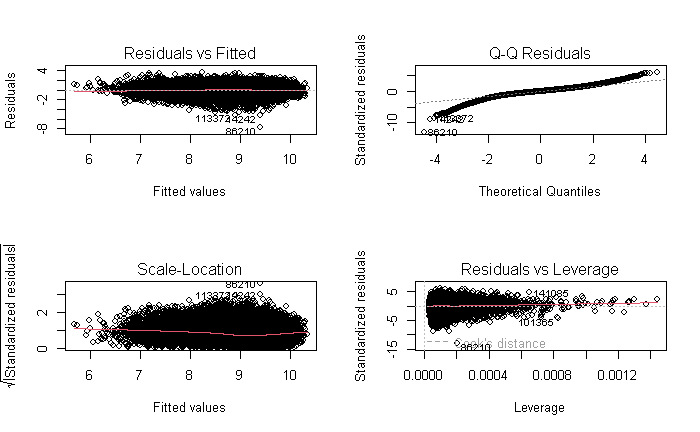

```r
par(mfrow = c(2, 2))
plot(modelo_vv_ocu1_bas)
```

Pruebas estadísticas

```r
# autocorrelación
lmtest::dwtest(modelo_vv_ocu1_bas)
```

```
    Durbin-Watson test

data:  modelo_vv_ocu1_bas
DW = 1.954, p-value = 9.321e-15
alternative hypothesis: true autocorrelation is greater than 0
```

## Jóvenes

### Modelo Verdugo

#### Con ocupaciones

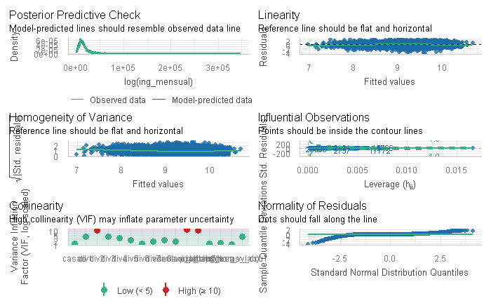

Pruebas estadísticas

```r
# autocorrelación
lmtest::dwtest(modelo_vv_jov_prof_amp)
```

```
    Durbin-Watson test

data:  modelo_vv_jov_prof_amp
DW = 1.9722, p-value = 0.01329
alternative hypothesis: true autocorrelation is greater than 0
```

## Criterios de información

### General

#### Con ocupaciones

|  | df | BIC |
| --- | --- | --- |
| modelo_vv_mod_ocu1_amp | 19 | 192832.0 |
| modelo_mincer_con_sr_mod | 20 | 192742.2 |

### Jóvenes

#### Con ocupaciones

|  | df | BIC |
| --- | --- | --- |
| modelo_vv_jov_prof_amp | 18 | 43863.52 |
| modelo_vv_mod_jov_prof_amp | 19 | 43856.58 |

# Resumen

General:

| Modelo | Método | R^2 | rsd(1) | coeficiente de sobre-educación | Nivel de significancia | Nota | Supuestos |
| --- | --- | --- | --- | --- | --- | --- | --- |
| Verdugo | Media | 0.4536 | 0.5772 | 4.349e-02 | 99.9% | Binaria | Ninguno |
| Verdugo | Moda | 0.4534 | 0.5773 | 1.780e-02 | 99% | Binaria | Ninguno |
| Verdugo | Mediana | 0.4534 | 0.5773 | 1.579e-02 | 99% | Binaria | Ninguno |
| ORU | Moda | 0.4534 | 0.5773 | 4.201e-02 | 99.9% | So > Sr | Ninguno |
| ORU | Mediana | 0.4534 | 0.5773 | 4.327e-02 | 99.9% | So > Sr | Ninguno |
| Mincer con Sr | Moda | 0.4539 | 0.577 | 1.723e-01 | 99.9% | Binaria | Ninguno |
| Mincer con Sr | Mediana | 0.4539 | 0.577 | 1.715e-01 | 99.9% | Binaria | Ninguno |

1. residual standard error

Jóvenes profesionistas, considerando licenciatura, maestría y doctorado

| Modelo | Método | R^2 | rsd(1) | coeficiente de sobre-educación | Nivel de significancia | Nota | Supuestos |
| --- | --- | --- | --- | --- | --- | --- | --- |
| Verdugo | Media | 0.2904 | 0.539 | 0.005250 | No significativo | Binaria | Ninguno |
| Verdugo | Moda | 0.2913 | 0.5387 | -0.0529586 | 99% | Binaria | Ninguno |
| Verdugo | Mediana | 0.2913 | 0.5387 | -0.0529586 | 99% | Binaria | Ninguno |
| ORU | Moda | 0.2913 | 0.5386 | 0.0557209 | 99.9% | So > Sr | Ninguno |
| ORU | Mediana | 0.2913 | 0.5386 | 0.0557209 | 99.9% | So > Sr | Ninguno |
| Mincer con Sr | Moda | 0.2913 | 0.5387 | 0.0272691 | No significativo | Binaria | Ninguno |
| Mincer con Sr | Mediana | 0.2913 | 0.5387 | 0.0272691 | No significativo | Binaria | Ninguno |

1. residual standard error

Jóvenes profesionistas, considerando sólo licenciatura

| Modelo | Método | R^2 | rsd(1) | coeficiente de sobre-educación | Nivel de significancia | Nota | Supuestos |
| --- | --- | --- | --- | --- | --- | --- | --- |
| Verdugo | Media | 0.288 | 0.5388 | -0.0119900 | No significativo | Binaria | Sin validar |
| Verdugo | Moda | 0.2892 | 0.5383 | -0.0604938 | 99% | Binaria | Sin validar |
| Verdugo | Mediana | 0.2892 | 0.5383 | -0.0604938 | 99% | Binaria | Sin validar |
| ORU | Moda | 0.2893 | 0.5383 | 0.0463654 | 99.9% | So > Sr | Sin validar |
| ORU | Mediana | 0.2893 | 0.5383 | 0.0463654 | 99.9% | So > Sr | Sin validar |
| Mincer con Sr | Moda | 0.2892 | 0.5383 | 0.0337033 | No significativo | Binaria | Sin validar |
| Mincer con Sr | Mediana | 0.2892 | 0.5383 | 0.0337033 | No significativo | Binaria | Sin validar |

Véase nota de Obsidian de 6-11-25

Cuando se añade variables dicotómicas relacionadas a los grupos ocupacionales (división) se observa que:

- Aumenta la medida de bondad de ajuste $R^2$ y disminuye la desviación estándar residual.
- Para el caso general, no existe un impacto en la tasa de retorno de la educación si la persona se encuentra sobre-educada, incluso es superior con respecto a individuos que no están sobre-educados.
- Para el caso de jóvenes profesionistas, con el modelo Verdugo sí se observa un impacto pero es menor al 10% (-0.0604938 tanto con el método de la moda o de la mediana) y con el modelo ORU la tasa de retorno de la sobre-educación es positiva y también superior a la educación requerida.
- En ningún caso, los modelos Verdugo y ORU cumplen con los supuestos asociados al residuo.

En síntesis, **NO EXISTEN PRUEBAS CONCLUYENTES QUE PERMITAN EVIDENCIAR UN IMPACTO NEGATIVO EN EL INGRESO DERIVADO DEL PROBLEMA DE LA SOBRE-EDUCACIÓN**

La pregunta subsecuente es ¿por qué?

En temas metodológicos, puede ser que el método estadístico no capture correctamente a las personas con desajuste educativo, es decir, determina a un individuo sobre-educado cuando en realidad no lo está. Situación que se respalda cuando se calcula el ingreso mensual promedio según el tipo de desajuste educativo, se observa que el ingreso es superior en el caso de sobre-educados con respecto a ajustados al puesto. En particular, puede ocurrir en el grupo ocupacional de mayor agregación (división): “1 Funcionarios, directores y jefes”.

¿Se puede corregir? Sí, construyendo los años de educación requeridos en cada ocupación a partir de los grupos ocupacionales de menor agregación (principal, subgrupo o unitario); no obstante, se realizó dicha construcción incluso con el grupo unitario y los resultados no presentaron cambios, es decir, el ingreso mensual promedio de los sobre-educados sigue siendo superior al de los requeridos. Cabe señalar que nos referimos al caso general, para jóvenes profesionistas (licenciatura, maestría y doctorado) de 25 a 34 años se observa un ingreso promedio menor cuando están sobre-educados.

Por otra parte, también se puede utilizar el método objetivo que utiliza la Organización Internacional del Trabajo (ILO, por sus siglas en inglés). Sin embargo, puede ocurrir la misma situación que con el método estadístico debido a que construyen los años requeridos con el grupo ocupacional de mayor agregación.

Lamentablemente, la disponibilidad de los datos no permiten utilizar el método subjetivo.

Más allá de la cuestión metodológica, puede ocurrir que las empresas sí estén aprovechando el excedente de capital humano que poseen los individuos sobre-educados, o dicho en otras palabras, los puestos de trabajo ya no imponen un límite de techo en la productividad del individuo sobre-cualificado. En caso de ocurrir tal situación, la pregunta sería ¿por qué antes sí y ahora ya no existe un límite de techo?